# accumbens_and_learning

Ben Smith

2022-10-18

We’ve noticed an accumbens signal that has a particularly pronounced CS-FS difference among late trials.

That led us to ask: is it correlated with reaction time; specifically,

1. is accumbens BOLD CS-FS contrast at tone+5 s (which reacts negatively) negatively related to longer reaction times in subsequent trials, and
2. is accumbens bold CS-FS contrast at tone+9 (which reacts positively) positively related to longer reaction times in subsequent trials?

We are really mostly interested in FS so at the trial level we’d do

1. is accumbens BOLD FS contrast at tone+5 s (which reacts positively) positively related to longer reaction times in subsequent trials, and
2. is accumbens bold FS contrast at tone+9 (which reacts negatively) negatively related to longer reaction times in subsequent trials?

```r
library(tidyverse)
library(ggpubr)
Sys.setenv(R_CONFIG_ACTIVE = Sys.info()["nodename"])
print(Sys.info()["nodename"])
```

```
##                        nodename
## "Benjamins-MacBook-Pro-2.local"
```

```r
dropbbox_dir <- config::get("dev_analysis_data_dir")
```

```r
time_points <- readr::read_csv(paste0(dropbbox_dir,"/SST_roi_by_time_point_oct.csv"))
```

```
## ──────────────────────────────────────────────────────── Delimiter: "," chr
## (3): subid, go_no_go_condition_label, condition dbl (14): ...1, tr, offset,
## harvardoxford-cortical_prob_Frontal Orbital Cort...
```

So how do we design this experiment; what are we correlating over, exactly? Some designs are:

1. Across subject, so:
1. apply the script I have created on late trials to get average measurements every 10 s–maybe the last half or third of the task, not just the last few, but do this at a per subject level
2. take the MAXIMUM accumbens activity at the 1-9 s range across trials for each subject (to get the peak), and the MINIMUM accumbens activity at the 4-12 s range (to get the trough)
3. correlate across subject average reaction times, or post-pre change in reaction times
2. Within subject, so:
1. get peak and trough accumbens signal for each FS trial in the last third of the task. Perhaps use the difference between the peak and trough as your measure. Though we’re really now kind of getting a crude HRF…the advantage of this measure is we aren’t bound to a particular shape of it, which is probably useful.
2. get (i) reaction time and (ii) post-pre difference for subsequent go trial
3. correlate the difference of peak and trough gathered in (a) with the two measures in (b). Summarize in two ways: i. get average correlations within-subject, then average across subjects as a crude multi-level model to test across subject ii. apply a true multi-level model

We’ll want to re-use existing pre-post data.

So–this will yield quite different data to the data we used previously!

```r
roi_cols <- colnames(time_points)[grepl("harvardoxford",colnames(time_points))]
time_points$tr_roi_mean <- rowMeans(time_points[,roi_cols])
time_points<-
  time_points %>% group_by(subid,wave) %>%
  mutate(run_mean_across_rois = mean(tr_roi_mean, na.rm = TRUE))

#now mean-center the ROIs
time_points_c<-time_points
for (roi_col in roi_cols){
  time_points_c[,roi_col]<-time_points_c[,roi_col]-time_points_c$run_mean_across_rois
}

#roi_cols <- colnames(time_points_c)[grepl("harvardoxford",colnames(time_points_c))]
#roi_cols_all <- colnames(time_points_c)#[grepl("((?<=harvardoxford-.{0,3}cortical_prob_)(.*))|(CueFollowing\\(CS\\>FS\\).*)",colnames(time_points_c),perl=TRUE)]
roi_detect_pattern<-"((?<=harvardoxford-.{0,3}cortical_prob_)(.*))|(CueFollowing\\(CS\\>FS\\).*)"

roi_cols_vec <- colnames(time_points_c) %>% stringr::str_detect(pattern = roi_detect_pattern)
new_roi_cols <- colnames(time_points_c) %>% stringr::str_extract_all(pattern = roi_detect_pattern) %>% unlist
unique(new_roi_cols)
```

```
## [1] "Frontal Orbital Cortex"             "Cingulate Gyrus, anterior division"
## [3] "Left Caudate"                       "Right Accumbens"
## [5] "Right Putamen"                      "Left Putamen"
## [7] "Right Caudate"                      "Left Accumbens"
```

```r
colnames(time_points_c)[roi_cols_vec] <- new_roi_cols
```

We need to group by subject, wave, and trial, select just the FailedStop trials, and just the high trial numbers, then get the min and max accumbens activity. We could even do a long transform across the ROIs, then also group by ROI and get the min and max for ROIs

So let’s first long transform the ROIs

```r
tpc_long<-time_points_c %>% pivot_longer(cols=all_of(new_roi_cols),names_to="ROI",values_to="value")
```

Now do the grouping and summarizing.

```r
FS_summary_data <- tpc_long %>%
  filter(condition=="FailedStop") %>%
  group_by(subid,wave,trial_n,ROI) %>%
  summarise(
    peak=max(value[offset>=2.0 & offset <=8.0],na.rm = TRUE),
    trough = min(value[offset>=0.0 & offset <=5.0],na.rm = TRUE),
    peak_time = offset[offset>=2.0 & offset <=8.0][value[offset>=2.0 & offset <=8.0]==max(value[offset>=2.0 & offset <=8.0],na.rm = TRUE)],
    trough_time = offset[offset>=0.0 & offset <=5.0][value[offset>=0.0 & offset <=5.0]==min(value[offset>=0.0 & offset <=5.0],na.rm = TRUE)]
  )
```

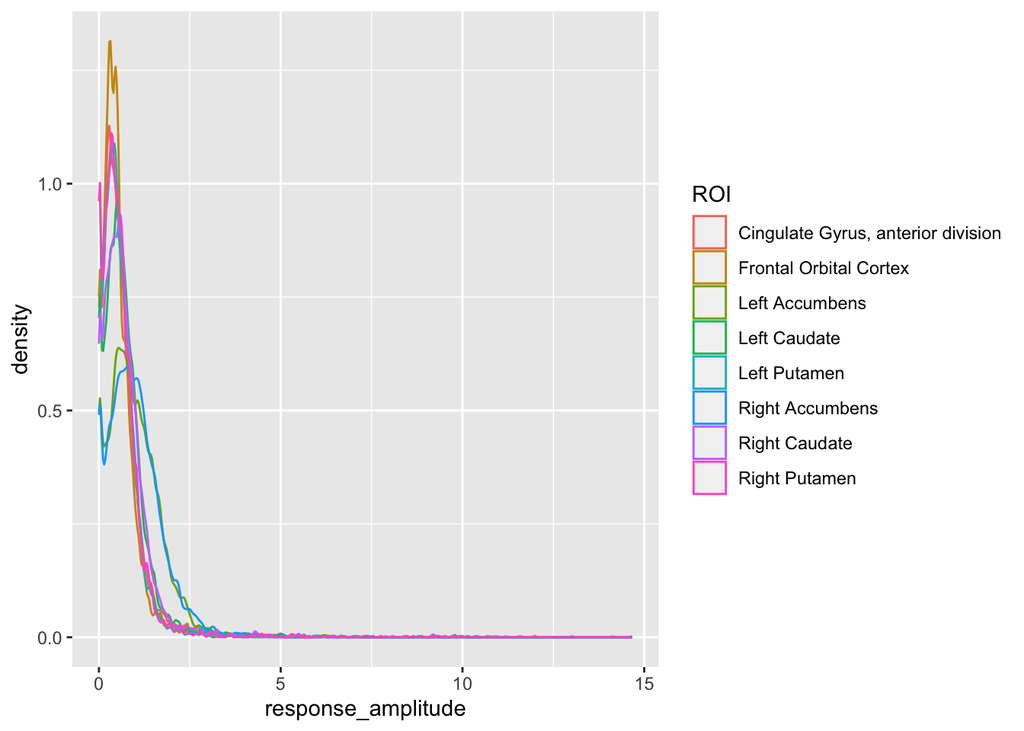

```r
FS_summary_data$response_amplitude <-FS_summary_data$peak-FS_summary_data$trough

ggplot(FS_summary_data,aes(response_amplitude,group=ROI,color=ROI))+geom_density(adjust=0.5)
```

OK. So now, let’s try to merge in that with post-pre RTs. Where do we get those from?

## get the SST Post-pre data

```r
source(paste0(config::get("ben_dev_data_analysis"),"SST_processing.R"))

dropbox_file_dir = config::get("dev_analysis_data_dir")
sst_all_data_filepath <- paste0(dropbox_file_dir,"sst_behavioral_data_all.csv")

sst_all_data_raw <- readr::read_csv(sst_all_data_filepath)
sst_all_data<-clean_sst_data(sst_all_data_raw)
sst_all_data <- get_expected_tone_time(sst_all_data)

sst_all_data<-calculate_response_latency(sst_all_data)
sst_all_data<-calculate_rpe(sst_all_data)


# sst_all_data %>% select(
#   subid, waveid, runid, reaction_time_clean, SSD_recorded,condition, last_tone_delay, trials_since_last_SSD,last_correct_go)# %>%
#   #View()
```

```r
readr::write_csv(sst_all_data,file=paste0(dropbox_file_dir,"sst_behavioral_data_all_with_analysis.csv"))
```

```r
post_pre_rt_data <- sst_all_data%>%
  filter(condition!="Cue") #%>%
  #select(trial_n,reaction_time,subid,waveid,runid,condition,post_pre_rt_change)
```

## Prepare neural data

```r
FS_summary_data$ROI_delateralized <-  FS_summary_data$ROI %>% str_replace_all("(Left|Right)\\s","")


FS_summary_data_delat <- FS_summary_data %>%
  #filter(ROI %in% c("Left Accumbens","Right Accumbens")) %>%
  group_by(subid,wave,trial_n, ROI_delateralized) %>%
  summarize(peak=mean(peak),
            trough=mean(trough),
            peak_time=mean(peak_time),
            trough_time=mean(trough_time),
            response_amplitude=mean(response_amplitude))
```

## Merge the datasets

```r
FS_summary_data_delat_pp <- merge(FS_summary_data_delat,post_pre_rt_data,by.x = c("subid","wave","trial_n"),by.y=c("subid","waveid","trial_n"),all.x = TRUE)

FS_summary_data_delat_pp$trial_n_c<-128-FS_summary_data_delat_pp$trial_n

FS_summary_data_accumbens <- FS_summary_data_delat_pp %>% filter(ROI_delateralized=="Accumbens") %>% select(-ROI_delateralized)



FS_neural_behav_data_not_na<-FS_summary_data_accumbens[
  rowSums(is.na(FS_summary_data_accumbens[,c("response_amplitude","post_pre_rt_change")]))==0 & #no NA values in correlation and
    is.finite(FS_summary_data_accumbens$response_amplitude) & is.finite(FS_summary_data_accumbens$post_pre_rt_change) #no infinite values
    ,]
```

#now test. let’s trun across all at first….

```r
cor.test(FS_neural_behav_data_not_na$response_amplitude,FS_neural_behav_data_not_na$post_pre_rt_change)
```

```
##
##  Pearson's product-moment correlation
##
## data:  FS_neural_behav_data_not_na$response_amplitude and FS_neural_behav_data_not_na$post_pre_rt_change
## t = 0.95411, df = 2463, p-value = 0.3401
## alternative hypothesis: true correlation is not equal to 0
## 95 percent confidence interval:
##  -0.02027404  0.05865704
## sample estimates:
##        cor
## 0.01922145
```

```r
cor.test(FS_neural_behav_data_not_na$peak,FS_neural_behav_data_not_na$post_pre_rt_change)
```

```
##
##  Pearson's product-moment correlation
##
## data:  FS_neural_behav_data_not_na$peak and FS_neural_behav_data_not_na$post_pre_rt_change
## t = -0.044933, df = 2463, p-value = 0.9642
## alternative hypothesis: true correlation is not equal to 0
## 95 percent confidence interval:
##  -0.04038405  0.03857609
## sample estimates:
##           cor
## -0.0009053898
```

```r
cor.test(FS_neural_behav_data_not_na$peak,FS_neural_behav_data_not_na$reaction_time)
```

```
##
##  Pearson's product-moment correlation
##
## data:  FS_neural_behav_data_not_na$peak and FS_neural_behav_data_not_na$reaction_time
## t = 1.0251, df = 2463, p-value = 0.3054
## alternative hypothesis: true correlation is not equal to 0
## 95 percent confidence interval:
##  -0.01884523  0.06008136
## sample estimates:
##        cor
## 0.02065024
```

```r
cor_val<-cor.test(FS_neural_behav_data_not_na$trough,FS_neural_behav_data_not_na$post_pre_rt_change)
print(cor_val)
```

```
##
##  Pearson's product-moment correlation
##
## data:  FS_neural_behav_data_not_na$trough and FS_neural_behav_data_not_na$post_pre_rt_change
## t = -1.0075, df = 2463, p-value = 0.3138
## alternative hypothesis: true correlation is not equal to 0
## 95 percent confidence interval:
##  -0.05972798  0.01919975
## sample estimates:
##         cor
## -0.02029574
```

```r
FS_by_subj_raw <- FS_neural_behav_data_not_na %>% group_by(subid) %>%
  mutate(trial_count=n())
FS_by_subj <- FS_by_subj_raw %>% filter(trial_count >2) %>%
  summarize(peak_cor_est = cor.test(peak,post_pre_rt_change)$estimate,
            amplitude_cor_est = cor.test(response_amplitude,post_pre_rt_change)$estimate,
            mean_post_pre_rt_change=mean(post_pre_rt_change),
            mean_post_current_rt_change=mean(post_current_rt_change),
            mean_peak=mean(peak),
            mean_trough=mean(trough),
            mean_amplitude=mean(response_amplitude),
            trial_count=n()
            )

t.test(FS_by_subj$peak_cor_est)
```

```
##
##  One Sample t-test
##
## data:  FS_by_subj$peak_cor_est
## t = 0.27982, df = 221, p-value = 0.7799
## alternative hypothesis: true mean is not equal to 0
## 95 percent confidence interval:
##  -0.04105830  0.05464697
## sample estimates:
##   mean of x
## 0.006794335
```

```r
t.test(FS_by_subj$amplitude_cor_est)
```

```
##
##  One Sample t-test
##
## data:  FS_by_subj$amplitude_cor_est
## t = -2.0156, df = 221, p-value = 0.04505
## alternative hypothesis: true mean is not equal to 0
## 95 percent confidence interval:
##  -0.092562522 -0.001041129
## sample estimates:
##   mean of x
## -0.04680183
```

OK. So our “amplitude” measure correlates within subjects (p<0.05), when measuring the correlations within subject and then taking the average.

Would strengthen the data

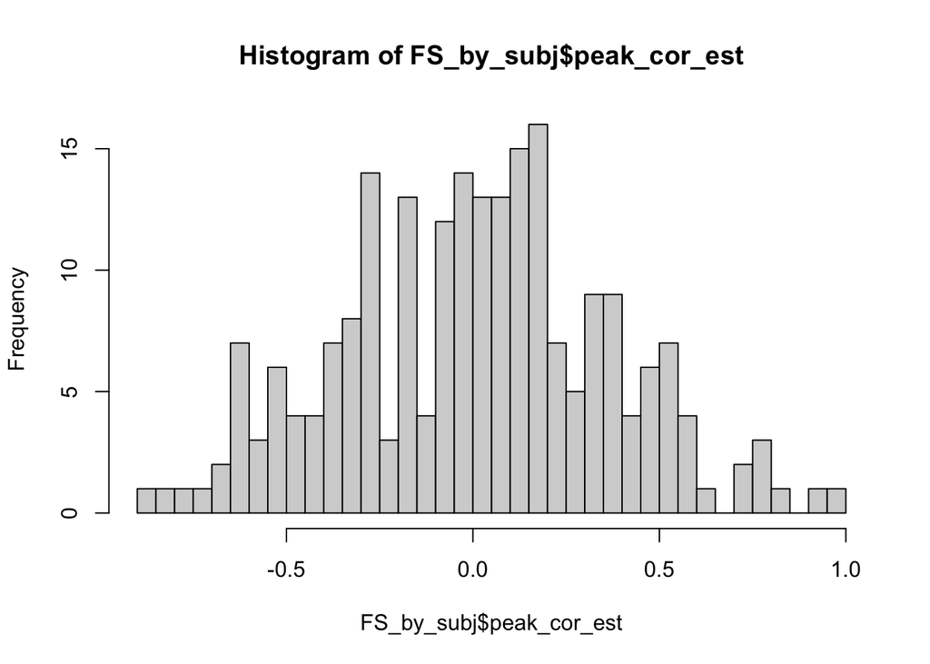

```r
hist(FS_by_subj$peak_cor_est,breaks=40)
```

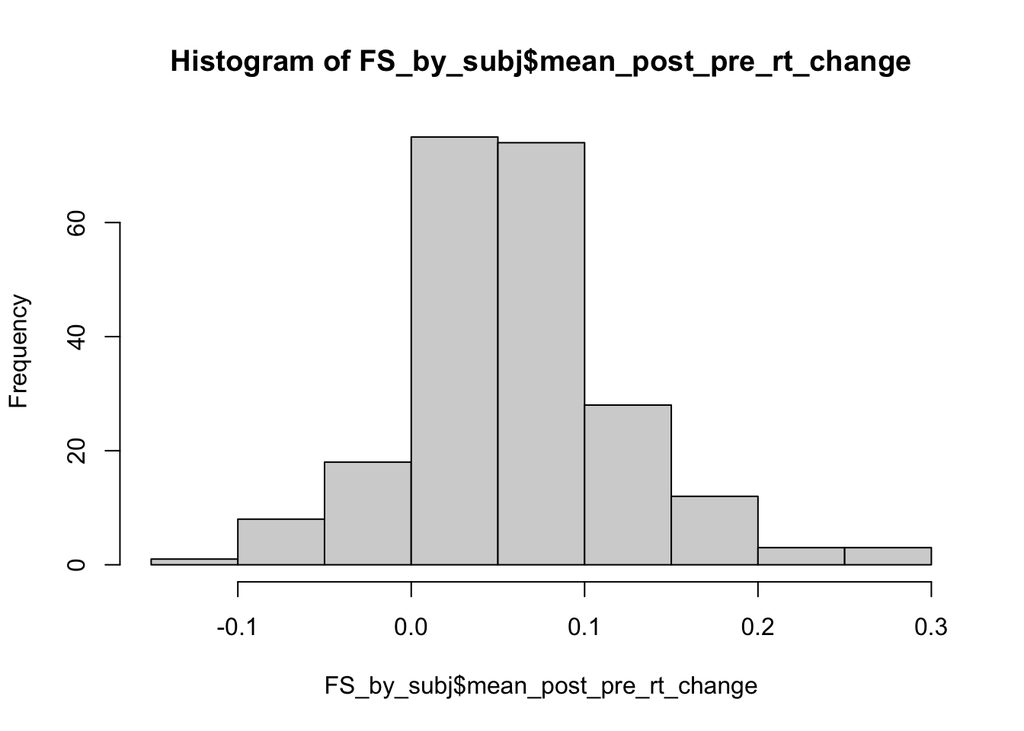

```r
hist(FS_by_subj$mean_post_pre_rt_change)
```

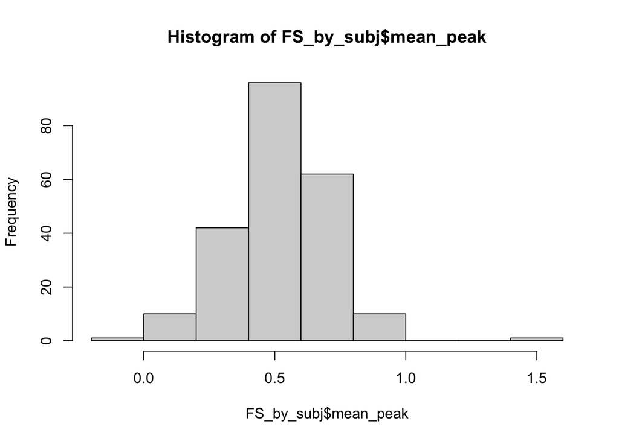

```r
hist(FS_by_subj$mean_peak)
```

```r
cor.test(FS_by_subj$mean_post_pre_rt_change,FS_by_subj$mean_trough)
```

```
##
##  Pearson's product-moment correlation
##
## data:  FS_by_subj$mean_post_pre_rt_change and FS_by_subj$mean_trough
## t = -2.137, df = 220, p-value = 0.0337
## alternative hypothesis: true correlation is not equal to 0
## 95 percent confidence interval:
##  -0.26922205 -0.01114024
## sample estimates:
##        cor
## -0.1426042
```

```r
cor.test(FS_by_subj$mean_post_pre_rt_change,FS_by_subj$mean_peak)
```

```
##
##  Pearson's product-moment correlation
##
## data:  FS_by_subj$mean_post_pre_rt_change and FS_by_subj$mean_peak
## t = 1.2311, df = 220, p-value = 0.2196
## alternative hypothesis: true correlation is not equal to 0
## 95 percent confidence interval:
##  -0.04949846  0.21207707
## sample estimates:
##        cor
## 0.08271374
```

```r
cor.test(FS_by_subj$mean_post_pre_rt_change,FS_by_subj$mean_amplitude)
```

```
##
##  Pearson's product-moment correlation
##
## data:  FS_by_subj$mean_post_pre_rt_change and FS_by_subj$mean_amplitude
## t = 2.7092, df = 220, p-value = 0.007276
## alternative hypothesis: true correlation is not equal to 0
## 95 percent confidence interval:
##  0.04916974 0.30415661
## sample estimates:
##       cor
## 0.1796795
```

```r
cor.test(FS_by_subj$mean_post_pre_rt_change,FS_by_subj$mean_peak,method="spearman")
```

```
##
##  Spearman's rank correlation rho
##
## data:  FS_by_subj$mean_post_pre_rt_change and FS_by_subj$mean_peak
## S = 1682710, p-value = 0.2518
## alternative hypothesis: true rho is not equal to 0
## sample estimates:
##        rho
## 0.07719399
```

If you take away the accumbens selection, you do get some significant results, but these are taking false precision…

## Between subjects

```r
FS_neural_behav_data_not_na<-FS_summary_data_delat_pp[
  rowSums(is.na(FS_summary_data_delat_pp[,c("response_amplitude","post_pre_rt_change")]))==0 & #no NA values in correlation and
    is.finite(FS_summary_data_delat_pp$response_amplitude) & is.finite(FS_summary_data_delat_pp$post_pre_rt_change) #no infinite values
    ,]
```

```r
full_run_data <- sst_all_data %>% group_by(subid,waveid,runid) %>%
  summarize(mean_SSD_all_stop_trials=mean(SSD_recorded[SSD_recorded!=0]))
FS_by_subj_raw <- FS_neural_behav_data_not_na %>% group_by(ROI_delateralized, subid) %>%
  mutate(trial_count=n())
FS_by_subj <- FS_by_subj_raw %>% group_by(ROI_delateralized, subid,trial_count) %>% filter(trial_count >2) %>%
  summarize(peak_cor_est = cor.test(peak,post_pre_rt_change)$estimate,
            trough_cor_est = cor.test(trough,post_pre_rt_change)$estimate,
            amplitude_cor_est = cor.test(response_amplitude,post_pre_rt_change)$estimate,
            mean_post_pre_rt_change=mean(post_pre_rt_change),
            mean_post_current_rt_change=mean(post_current_rt_change),
            mean_post_rt=mean(next_reaction_time),
            mean_peak=mean(peak),
            mean_trough=mean(trough),
            mean_amplitude=mean(response_amplitude),
            mean_peak_offset=mean(peak_time),
            mean_trough_offset=mean(trough_time),

            )
FS_by_subj<-merge(FS_by_subj,
                  full_run_data %>% filter(runid==1 & waveid==1),
                  by='subid',how='left'
                  )

FS_neural_behav_data_not_na <- merge(
  FS_neural_behav_data_not_na,
  full_run_data %>% filter(runid==1 & waveid==1),
                  by='subid',how='left'
                  )
```

Per subject:

```r
roi_within_subj_list<-list()

for (roi_i in unique(FS_by_subj$ROI_delateralized)){
  # cat("\n")
  # cat(roi_i)
  # cat("\n")
  peak<-t.test(FS_by_subj %>% filter(ROI_delateralized==roi_i) %>% .$peak_cor_est)
  trough<-t.test(FS_by_subj %>% filter(ROI_delateralized==roi_i) %>% .$trough_cor_est)
  amplitude<-t.test(FS_by_subj %>% filter(ROI_delateralized==roi_i) %>% .$amplitude_cor_est)
  # print(peak)
  # print(trough)
  # print(amplitude)

  roi_within_subj_row<-data.frame("roi"=roi_i,"measure"="peak","t"=peak[[1]],"estimate"=peak$estimate, "pvalue"=peak$p.value)
  roi_within_subj_list<-append(roi_within_subj_list,list(roi_within_subj_row))
  roi_within_subj_row<-data.frame("roi"=roi_i,"measure"="trough","t"=trough[[1]],"estimate"=trough$estimate, "pvalue"=trough$p.value)
  roi_within_subj_list<-append(roi_within_subj_list,list(roi_within_subj_row))
  roi_within_subj_row<-data.frame("roi"=roi_i,"measure"="amplitude","t"=amplitude[[1]],"estimate"=amplitude$estimate, "pvalue"=amplitude$p.value)
  roi_within_subj_list<-append(roi_within_subj_list,list(roi_within_subj_row))
  # cat("---\n")
}
print("example:")
```

```
## [1] "example:"
```

```r
cat(roi_i)
```

```
## Putamen
```

```r
cat("\n")
```

```r
print(peak)
```

```
##
##  One Sample t-test
##
## data:  FS_by_subj %>% filter(ROI_delateralized == roi_i) %>% .$peak_cor_est
## t = 0.32557, df = 221, p-value = 0.7451
## alternative hypothesis: true mean is not equal to 0
## 95 percent confidence interval:
##  -0.03952712  0.05517138
## sample estimates:
##   mean of x
## 0.007822127
```

```r
  print(trough)
```

```
##
##  One Sample t-test
##
## data:  FS_by_subj %>% filter(ROI_delateralized == roi_i) %>% .$trough_cor_est
## t = 1.2348, df = 221, p-value = 0.2182
## alternative hypothesis: true mean is not equal to 0
## 95 percent confidence interval:
##  -0.01753608  0.07637950
## sample estimates:
##  mean of x
## 0.02942171
```

```r
  print(amplitude)
```

```
##
##  One Sample t-test
##
## data:  FS_by_subj %>% filter(ROI_delateralized == roi_i) %>% .$amplitude_cor_est
## t = -1.5151, df = 221, p-value = 0.1312
## alternative hypothesis: true mean is not equal to 0
## 95 percent confidence interval:
##  -0.08151002  0.01065462
## sample estimates:
##  mean of x
## -0.0354277
```

```r
  cat("---\n")
roi_within_subj_df <- do.call(rbind,roi_within_subj_list)

library(stats)
roi_within_subj_df$pvalue_fdr_adjust<-p.adjust(roi_within_subj_df$pvalue,method="fdr")
roi_within_subj_df <- roi_within_subj_df %>% mutate(signif=ifelse(pvalue_fdr_adjust<0.05,"*",""))

print("summary:")
```

```
## [1] "summary:"
```

```r
print(roi_within_subj_df)
```

```
##                                    roi   measure          t      estimate
## t                            Accumbens      peak  0.2798170  0.0067943346
## t1                           Accumbens    trough  1.7155364  0.0398613098
## t2                           Accumbens amplitude -2.0155941 -0.0468018255
## t3  Cingulate Gyrus, anterior division      peak  1.1568402  0.0285836162
## t4  Cingulate Gyrus, anterior division    trough  1.3123635  0.0310933265
## t5  Cingulate Gyrus, anterior division amplitude -0.0310033 -0.0007391081
## t6              Frontal Orbital Cortex      peak  2.0337894  0.0510178561
## t7              Frontal Orbital Cortex    trough  2.4236179  0.0584936389
## t8              Frontal Orbital Cortex amplitude -1.2098673 -0.0294501996
## t9                             Caudate      peak  0.7498873  0.0179454050
## t10                            Caudate    trough  0.1837521  0.0046588750
## t11                            Caudate amplitude -0.2603748 -0.0066603045
## t12                            Putamen      peak  0.3255702  0.0078221273
## t13                            Putamen    trough  1.2347902  0.0294217093
## t14                            Putamen amplitude -1.5151011 -0.0354277043
##         pvalue pvalue_fdr_adjust signif
## t   0.77987966         0.9154033
## t1  0.08764845         0.3286817
## t2  0.04505323         0.2252661
## t3  0.24858654         0.4143109
## t4  0.19075887         0.4143109
## t5  0.97529489         0.9752949
## t6  0.04316775         0.2252661
## t7  0.01617135         0.2252661
## t8  0.22762235         0.4143109
## t9  0.45412010         0.6811802
## t10 0.85437643         0.9154033
## t11 0.79481712         0.9154033
## t12 0.74505756         0.9154033
## t13 0.21821984         0.4143109
## t14 0.13117574         0.3935272
```

Look ## across subjects

```r
roi_inddiv_list<-list()
for (roi_i in unique(FS_by_subj$ROI_delateralized)){
  cat("\n")
  cat(roi_i)
  cat("\n")
  FS_by_subj_i <- FS_by_subj %>% filter(ROI_delateralized==roi_i)

  peak<-cor.test(FS_by_subj_i$mean_post_pre_rt_change,FS_by_subj_i$mean_peak)
  trough<-cor.test(FS_by_subj_i$mean_post_pre_rt_change,FS_by_subj_i$mean_trough)
  amplitude<-cor.test(FS_by_subj_i$mean_post_pre_rt_change,FS_by_subj_i$mean_amplitude)
  #roi_inddiv_row<-data.frame("roi"=character(0),"measure"=character(0),"value"=numeric(0))
  roi_inddiv_row<-data.frame("roi"=roi_i,"measure"="peak","value"=peak[[1]],"estimate"=peak$estimate,"pvalue"=peak$p.value)
  roi_inddiv_list<-append(roi_inddiv_list,list(roi_inddiv_row))
  roi_inddiv_row<-data.frame("roi"=roi_i,"measure"="trough","value"=trough[[1]],"estimate"=trough$estimate,"pvalue"=trough$p.value)
  roi_inddiv_list<-append(roi_inddiv_list,list(roi_inddiv_row))
  roi_inddiv_row<-data.frame("roi"=roi_i,"measure"="amplitude","value"=amplitude[[1]],"estimate"=amplitude$estimate,"pvalue"=amplitude$p.value)
  roi_inddiv_list<-append(roi_inddiv_list,list(roi_inddiv_row))
  # print(peak)
  # print(trough)
  # print(amplitude)
  # cat("---\n")
}
```

```
##
## Accumbens
##
## Cingulate Gyrus, anterior division
##
## Frontal Orbital Cortex
##
## Caudate
##
## Putamen
```

```r
print("example of full analyses for last ROI")
```

```
## [1] "example of full analyses for last ROI"
```

```r
cat(roi_i)
```

```
## Putamen
```

```r
  cat("\n")
```

```r
print(peak)
```

```
##
##  Pearson's product-moment correlation
##
## data:  FS_by_subj_i$mean_post_pre_rt_change and FS_by_subj_i$mean_peak
## t = 0.82593, df = 220, p-value = 0.4097
## alternative hypothesis: true correlation is not equal to 0
## 95 percent confidence interval:
##  -0.07663633  0.18590991
## sample estimates:
##        cor
## 0.05559781
```

```r
print(trough)
```

```
##
##  Pearson's product-moment correlation
##
## data:  FS_by_subj_i$mean_post_pre_rt_change and FS_by_subj_i$mean_trough
## t = -2.6995, df = 220, p-value = 0.007484
## alternative hypothesis: true correlation is not equal to 0
## 95 percent confidence interval:
##  -0.30357396 -0.04852935
## sample estimates:
##        cor
## -0.1790583
```

```r
print(amplitude)
```

```
##
##  Pearson's product-moment correlation
##
## data:  FS_by_subj_i$mean_post_pre_rt_change and FS_by_subj_i$mean_amplitude
## t = 3.0063, df = 220, p-value = 0.002951
## alternative hypothesis: true correlation is not equal to 0
## 95 percent confidence interval:
##  0.06877322 0.32190075
## sample estimates:
##       cor
## 0.1986475
```

```r
cat("---\n")
print("summary")
```

```
## [1] "summary"
```

```r
roi_inddiv_df <- do.call(rbind,roi_inddiv_list)

library(stats)
roi_inddiv_df$pvalue_fdr_adjust<-p.adjust(roi_inddiv_df$pvalue,method="fdr")
roi_inddiv_df <- roi_inddiv_df %>% mutate(signif=ifelse(pvalue_fdr_adjust<0.05,"*",""))

print(roi_inddiv_df)
```

```
##                                    roi   measure      value    estimate
## t                            Accumbens      peak  1.2310614  0.08271374
## t1                           Accumbens    trough -2.1370022 -0.14260416
## t2                           Accumbens amplitude  2.7091695  0.17967954
## t3  Cingulate Gyrus, anterior division      peak  0.9239394  0.06217147
## t4  Cingulate Gyrus, anterior division    trough -2.2410145 -0.14939362
## t5  Cingulate Gyrus, anterior division amplitude  2.5985006  0.17256275
## t6              Frontal Orbital Cortex      peak  1.3824087  0.09279979
## t7              Frontal Orbital Cortex    trough -1.8682670 -0.12497107
## t8              Frontal Orbital Cortex amplitude  2.5067943  0.16664480
## t9                             Caudate      peak  0.5619863  0.03786194
## t10                            Caudate    trough -2.6461425 -0.17562984
## t11                            Caudate amplitude  2.8162821  0.18654089
## t12                            Putamen      peak  0.8259263  0.05559781
## t13                            Putamen    trough -2.6994912 -0.17905826
## t14                            Putamen amplitude  3.0063310  0.19864745
##          pvalue pvalue_fdr_adjust signif
## t   0.219614360        0.27451795
## t1  0.033701539        0.05616923
## t2  0.007276236        0.02499014      *
## t3  0.356530152        0.41138094
## t4  0.026023908        0.04879483      *
## t5  0.009996057        0.02499014      *
## t6  0.168248020        0.22942912
## t7  0.063054214        0.09458132
## t8  0.012906282        0.02765632      *
## t9  0.574697431        0.57469743
## t10 0.008729526        0.02499014      *
## t11 0.005299820        0.02499014      *
## t12 0.409740685        0.43900788
## t13 0.007484156        0.02499014      *
## t14 0.002951404        0.02499014      *
```

# between-subjects correlations post_current and rt

```r
roi_inddiv_list<-list()
#for (roi_i in unique(FS_by_subj$ROI_delateralized)){
roi_i<-"Putamen"
  cat("\n")
```

```r
  cat(roi_i)
```

```
## Putamen
```

```r
  cat("\n")
```

```r
  FS_by_subj_i <- FS_by_subj %>% filter(ROI_delateralized==roi_i)

  peak<-cor.test(FS_by_subj_i$mean_post_current_rt_change,FS_by_subj_i$mean_peak)
  trough<-cor.test(FS_by_subj_i$mean_post_current_rt_change,FS_by_subj_i$mean_trough)
  amplitude<-cor.test(FS_by_subj_i$mean_post_current_rt_change,FS_by_subj_i$mean_amplitude)

  print(peak)
```

```
##
##  Pearson's product-moment correlation
##
## data:  FS_by_subj_i$mean_post_current_rt_change and FS_by_subj_i$mean_peak
## t = -0.71325, df = 211, p-value = 0.4765
## alternative hypothesis: true correlation is not equal to 0
## 95 percent confidence interval:
##  -0.18227304  0.08595526
## sample estimates:
##        cor
## -0.0490431
```

```r
  print(trough)
```

```
##
##  Pearson's product-moment correlation
##
## data:  FS_by_subj_i$mean_post_current_rt_change and FS_by_subj_i$mean_trough
## t = -2.5975, df = 211, p-value = 0.01005
## alternative hypothesis: true correlation is not equal to 0
## 95 percent confidence interval:
##  -0.30328364 -0.04260538
## sample estimates:
##        cor
## -0.1760288
```

```r
  print(amplitude)
```

```
##
##  Pearson's product-moment correlation
##
## data:  FS_by_subj_i$mean_post_current_rt_change and FS_by_subj_i$mean_amplitude
## t = 2.0255, df = 211, p-value = 0.04408
## alternative hypothesis: true correlation is not equal to 0
## 95 percent confidence interval:
##  0.003743055 0.267569264
## sample estimates:
##       cor
## 0.1381052
```

```r
  cat("---\n")
  FS_by_subj_i <- FS_by_subj %>% filter(ROI_delateralized==roi_i)

  peak<-cor.test(FS_by_subj_i$mean_post_rt,FS_by_subj_i$mean_peak)
  trough<-cor.test(FS_by_subj_i$mean_post_rt,FS_by_subj_i$mean_trough)
  amplitude<-cor.test(FS_by_subj_i$mean_post_rt,FS_by_subj_i$mean_amplitude)
  print(peak)
```

```
##
##  Pearson's product-moment correlation
##
## data:  FS_by_subj_i$mean_post_rt and FS_by_subj_i$mean_peak
## t = 0.7514, df = 186, p-value = 0.4534
## alternative hypothesis: true correlation is not equal to 0
## 95 percent confidence interval:
##  -0.08879709  0.19657488
## sample estimates:
##        cor
## 0.05501223
```

```r
  print(trough)
```

```
##
##  Pearson's product-moment correlation
##
## data:  FS_by_subj_i$mean_post_rt and FS_by_subj_i$mean_trough
## t = -0.99691, df = 186, p-value = 0.3201
## alternative hypothesis: true correlation is not equal to 0
## 95 percent confidence interval:
##  -0.21378207  0.07094822
## sample estimates:
##         cor
## -0.07290223
```

```r
  print(amplitude)
```

```
##
##  Pearson's product-moment correlation
##
## data:  FS_by_subj_i$mean_post_rt and FS_by_subj_i$mean_amplitude
## t = 1.3323, df = 186, p-value = 0.1844
## alternative hypothesis: true correlation is not equal to 0
## 95 percent confidence interval:
##  -0.04653074  0.23703898
## sample estimates:
##        cor
## 0.09722694
```

```r
  cat("---\n")
```

## Putamen

*Now* we see putamen activity.

```r
.05/0.002951 #putamen, amplitude,
```

```
## [1] 16.94341
```

```r
.05/0.007484 #putamen, trough
```

```
## [1] 6.680919
```

This result would withstand 17 multiple comparisons; considering the theoretical validty of the finding I think that is good enough.

Only trouble is that it wasn’t really of theoretical interest from the start.

I’m also wary that I ahve tried to interpret strongly “significant results” using this sort of fishing method before and it didn’t end up working.

Anyway–let’s graph, then multi-level model.

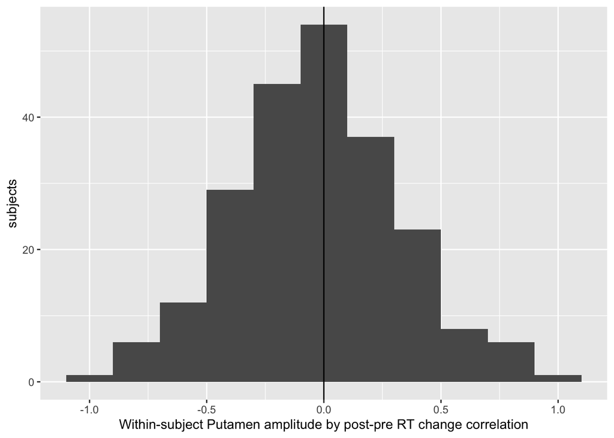

```r
ggplot(FS_by_subj %>% filter(ROI_delateralized=="Putamen"),
       aes(amplitude_cor_est))+geom_histogram(binwidth=0.2)+
  labs(y="subjects",x="Within-subject Putamen amplitude by post-pre RT change correlation")+
  geom_vline(xintercept = 0)
```

```r
t.test(FS_by_subj %>% filter(ROI_delateralized=="Putamen") %>% .$amplitude_cor_est)
```

```
##
##  One Sample t-test
##
## data:  FS_by_subj %>% filter(ROI_delateralized == "Putamen") %>% .$amplitude_cor_est
## t = -1.5151, df = 221, p-value = 0.1312
## alternative hypothesis: true mean is not equal to 0
## 95 percent confidence interval:
##  -0.08151002  0.01065462
## sample estimates:
##  mean of x
## -0.0354277
```

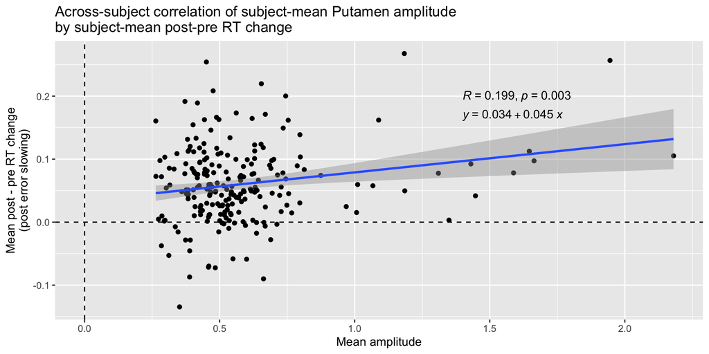

```r
#library(ggpubr)
library(ggrepel)
ggplot(FS_by_subj %>% filter(ROI_delateralized=="Putamen"),
       aes(x=mean_amplitude,y=mean_post_pre_rt_change))+geom_point(binwidth=0.2)+#geom_text(size=3,nudge_x=0.1)
  labs(title="Across-subject correlation of subject-mean Putamen amplitude\nby subject-mean post-pre RT change",x="Mean amplitude",y="Mean post - pre RT change\n(post error slowing)")+
  geom_hline(yintercept = 0,linetype="dashed")+geom_vline(xintercept = 0,linetype="dashed")+
  geom_smooth(method='lm')+
  stat_cor(label.x = 1.4, label.y = 0.20,r.digits=3,p.digits=1) +
  stat_regline_equation(label.x=1.4,label.y=0.17)
```

```r
cor.test(FS_by_subj_i %>% filter(ROI_delateralized=="Putamen") %>% .$mean_post_pre_rt_change,
         FS_by_subj_i %>% filter(ROI_delateralized=="Putamen") %>% .$mean_amplitude)
```

```
##
##  Pearson's product-moment correlation
##
## data:  FS_by_subj_i %>% filter(ROI_delateralized == "Putamen") %>% .$mean_post_pre_rt_change and FS_by_subj_i %>% filter(ROI_delateralized == "Putamen") %>% .$mean_amplitude
## t = 3.0063, df = 220, p-value = 0.002951
## alternative hypothesis: true correlation is not equal to 0
## 95 percent confidence interval:
##  0.06877322 0.32190075
## sample estimates:
##       cor
## 0.1986475
```

```r
cor.test(FS_by_subj_i %>% filter(ROI_delateralized=="Putamen") %>% .$mean_post_pre_rt_change,
         FS_by_subj_i %>% filter(ROI_delateralized=="Putamen") %>% .$mean_amplitude,
         method="spearman")
```

```
##
##  Spearman's rank correlation rho
##
## data:  FS_by_subj_i %>% filter(ROI_delateralized == "Putamen") %>% .$mean_post_pre_rt_change and FS_by_subj_i %>% filter(ROI_delateralized == "Putamen") %>% .$mean_amplitude
## S = 1690850, p-value = 0.2804
## alternative hypothesis: true rho is not equal to 0
## sample estimates:
##        rho
## 0.07272997
```

```r
#what if we remove the outliers altogether?
FS_by_subj_i_no_outliers <-FS_by_subj_i%>% filter(ROI_delateralized=="Putamen" & mean_amplitude<0.9)
cor.test(FS_by_subj_i_no_outliers$mean_post_pre_rt_change,FS_by_subj_i_no_outliers$mean_amplitude)
```

```
##
##  Pearson's product-moment correlation
##
## data:  FS_by_subj_i_no_outliers$mean_post_pre_rt_change and FS_by_subj_i_no_outliers$mean_amplitude
## t = 1.1394, df = 204, p-value = 0.2559
## alternative hypothesis: true correlation is not equal to 0
## 95 percent confidence interval:
##  -0.0578057  0.2139000
## sample estimates:
##        cor
## 0.07952401
```

```r
#it does seem to be driven by a few anomalous subjects. who the fuck are they and how do we describe them?
```

OK, it looks like an across-subject effect, and driven mainly by a few subjects.

This would explain why we don’t see the effect within-subject.

### can we explain why we’re seeing those outliers?

#### trial count

```r
trial_count = sst_all_data %>%
  filter(condition!="Cue") %>%
  group_by(subid,runid,waveid) %>%
  summarize(trial_count=n())
table(trial_count$trial_count)
```

```
##
##  128  640
## 1049    1
```

```r
time_points %>% group_by(subid, wave) %>% summarize(max_tr=max(tr)) %>% .$max_tr %>% table
```

```
## .
## 412 422
##   1 224
```

```r
#no, can't be explained by short runs. almost all subjects have the same number of trials in the behavioral data and the same number of TRs in the neural data
```

#### mean delay of the trough from the stop signal?

```r
summary(lm(mean_amplitude~mean_post_pre_rt_change,FS_by_subj %>% filter(ROI_delateralized=="Putamen")))
```

```
##
## Call:
## lm(formula = mean_amplitude ~ mean_post_pre_rt_change, data = FS_by_subj %>%
##     filter(ROI_delateralized == "Putamen"))
##
## Residuals:
##      Min       1Q   Median       3Q      Max
## -0.40105 -0.15898 -0.04427  0.05735  1.56437
##
## Coefficients:
##                         Estimate Std. Error t value Pr(>|t|)
## (Intercept)              0.52321    0.02513  20.821  < 2e-16 ***
## mean_post_pre_rt_change  0.88108    0.29307   3.006  0.00295 **
## ---
## Signif. codes:  0 '***' 0.001 '**' 0.01 '*' 0.05 '.' 0.1 ' ' 1
##
## Residual standard error: 0.2676 on 220 degrees of freedom
## Multiple R-squared:  0.03946,    Adjusted R-squared:  0.03509
## F-statistic: 9.038 on 1 and 220 DF,  p-value: 0.002951
```

```r
summary(lm(mean_amplitude~mean_post_pre_rt_change+mean_trough_offset,FS_by_subj %>% filter(ROI_delateralized=="Putamen")))
```

```
##
## Call:
## lm(formula = mean_amplitude ~ mean_post_pre_rt_change + mean_trough_offset,
##     data = FS_by_subj %>% filter(ROI_delateralized == "Putamen"))
##
## Residuals:
##      Min       1Q   Median       3Q      Max
## -0.40413 -0.14808 -0.04618  0.05203  1.44043
##
## Coefficients:
##                         Estimate Std. Error t value Pr(>|t|)
## (Intercept)              0.97061    0.10712   9.061  < 2e-16 ***
## mean_post_pre_rt_change  0.83041    0.28239   2.941  0.00363 **
## mean_trough_offset      -0.18281    0.04264  -4.287 2.71e-05 ***
## ---
## Signif. codes:  0 '***' 0.001 '**' 0.01 '*' 0.05 '.' 0.1 ' ' 1
##
## Residual standard error: 0.2576 on 219 degrees of freedom
## Multiple R-squared:  0.1138, Adjusted R-squared:  0.1057
## F-statistic: 14.07 on 2 and 219 DF,  p-value: 1.788e-06
```

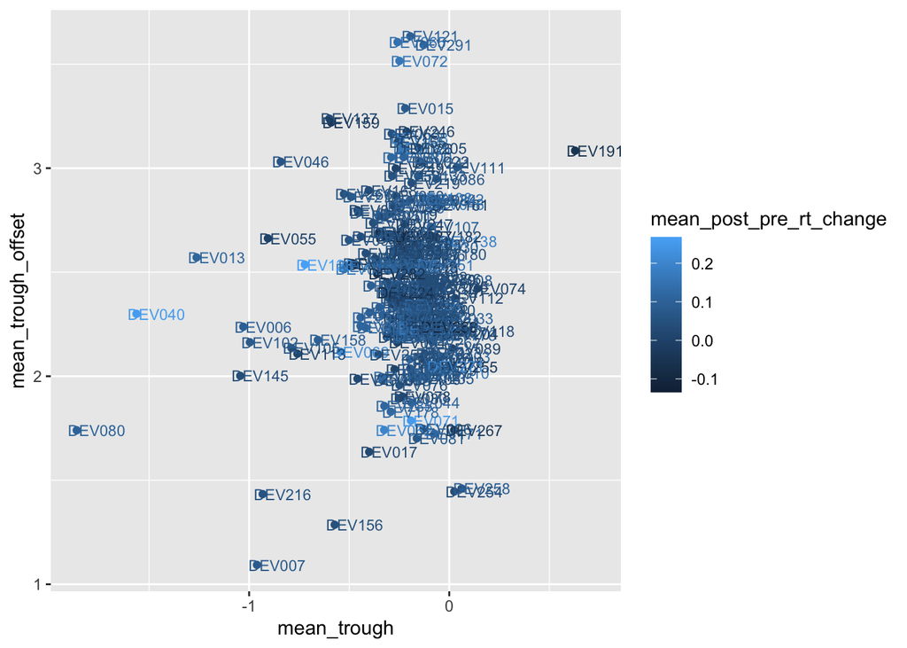

```r
ggplot(FS_by_subj %>% filter(ROI_delateralized=="Putamen"),
       aes(x=mean_trough,y=mean_trough_offset,
           label=subid,color=mean_post_pre_rt_change))+geom_point(binwidth=0.2)+geom_text(size=3,nudge_x=0.1)
```

```r
  labs(title="Across-subject correlation of subject-mean Putamen amplitude\nby subject-mean post-pre RT change")
```

```
## $title
## [1] "Across-subject correlation of subject-mean Putamen amplitude\nby subject-mean post-pre RT change"
##
## attr(,"class")
## [1] "labels"
```

That’s interesting, but it doesn’t really explain away the amplitude by RT change relationship.

#### What about subject SSD?

Due to the ladder, the shorter the mean SSD, the btter that participant has performed.

```r
summary(lm(mean_amplitude~mean_post_pre_rt_change,FS_by_subj %>% filter(ROI_delateralized=="Putamen")))
```

```
##
## Call:
## lm(formula = mean_amplitude ~ mean_post_pre_rt_change, data = FS_by_subj %>%
##     filter(ROI_delateralized == "Putamen"))
##
## Residuals:
##      Min       1Q   Median       3Q      Max
## -0.40105 -0.15898 -0.04427  0.05735  1.56437
##
## Coefficients:
##                         Estimate Std. Error t value Pr(>|t|)
## (Intercept)              0.52321    0.02513  20.821  < 2e-16 ***
## mean_post_pre_rt_change  0.88108    0.29307   3.006  0.00295 **
## ---
## Signif. codes:  0 '***' 0.001 '**' 0.01 '*' 0.05 '.' 0.1 ' ' 1
##
## Residual standard error: 0.2676 on 220 degrees of freedom
## Multiple R-squared:  0.03946,    Adjusted R-squared:  0.03509
## F-statistic: 9.038 on 1 and 220 DF,  p-value: 0.002951
```

```r
summary(lm(mean_amplitude~mean_post_pre_rt_change+mean_SSD_all_stop_trials,FS_by_subj %>% filter(ROI_delateralized=="Putamen")))
```

```
##
## Call:
## lm(formula = mean_amplitude ~ mean_post_pre_rt_change + mean_SSD_all_stop_trials,
##     data = FS_by_subj %>% filter(ROI_delateralized == "Putamen"))
##
## Residuals:
##      Min       1Q   Median       3Q      Max
## -0.39894 -0.16101 -0.04512  0.05480  1.60084
##
## Coefficients:
##                          Estimate Std. Error t value Pr(>|t|)
## (Intercept)               0.56235    0.04944  11.374  < 2e-16 ***
## mean_post_pre_rt_change   0.93229    0.29842   3.124  0.00202 **
## mean_SSD_all_stop_trials -0.16935    0.18422  -0.919  0.35896
## ---
## Signif. codes:  0 '***' 0.001 '**' 0.01 '*' 0.05 '.' 0.1 ' ' 1
##
## Residual standard error: 0.2677 on 219 degrees of freedom
## Multiple R-squared:  0.04315,    Adjusted R-squared:  0.03441
## F-statistic: 4.938 on 2 and 219 DF,  p-value: 0.007984
```

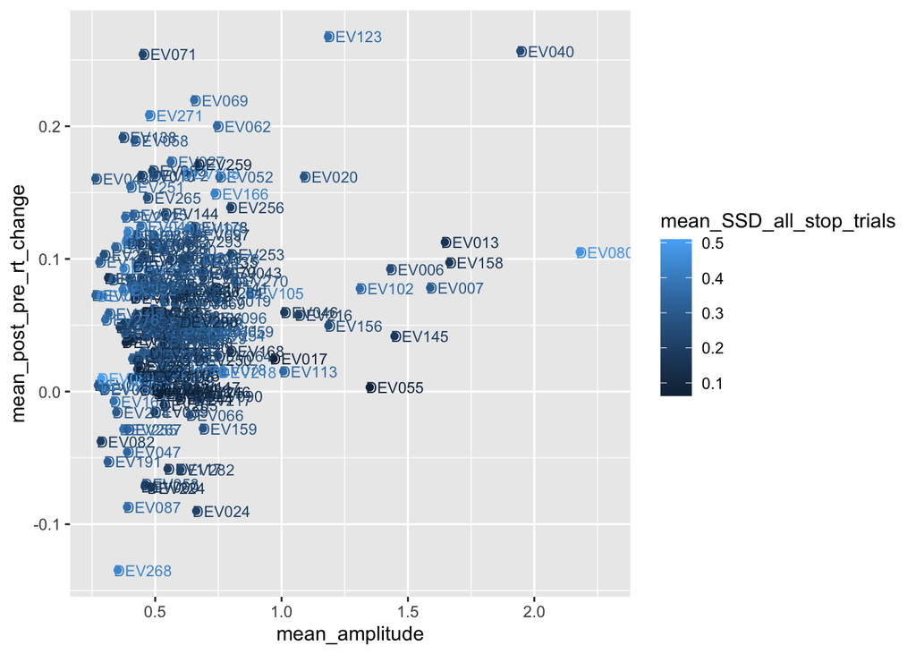

```r
ggplot(FS_by_subj %>% filter(ROI_delateralized=="Putamen"),
       aes(x=mean_amplitude,y=mean_post_pre_rt_change,
           label=subid,color=mean_SSD_all_stop_trials))+geom_point(binwidth=0.2)+geom_text(size=3,nudge_x=0.1)
```

```r
  labs(title="Across-subject correlation of subject-mean Putamen amplitude\nby subject-mean post-pre RT change")
```

```
## $title
## [1] "Across-subject correlation of subject-mean Putamen amplitude\nby subject-mean post-pre RT change"
##
## attr(,"class")
## [1] "labels"
```

```r
#not related to performance!
```

## Modeling effects

If we do a multi-level model, with response amplitude as a within-group slope, we need to be able to measure whether the estimate of that within-group slope differs from zero. If we add it as a random effect, I don’t think we can do that…?

```r
library(lme4)
#FS_neural_behav_data_not_na$trial_n_c<-128-FS_neural_behav_data_not_na$trial_n
FS_neural_behav_p <- FS_neural_behav_data_not_na %>% filter(ROI_delateralized=="Putamen")

model_random_effects <- lme4::lmer(
   post_pre_rt_change ~ trial_n_c +I(trial_n_c^2) + response_amplitude + (1+ response_amplitude | subid),
  FS_neural_behav_p
  )
summary(model_random_effects)
```

```
## Linear mixed model fit by REML ['lmerMod']
## Formula:
## post_pre_rt_change ~ trial_n_c + I(trial_n_c^2) + response_amplitude +
##     (1 + response_amplitude | subid)
##    Data: FS_neural_behav_p
##
## REML criterion at convergence: -2092.6
##
## Scaled residuals:
##     Min      1Q  Median      3Q     Max
## -3.6119 -0.5798 -0.0371  0.5472  3.7325
##
## Random effects:
##  Groups   Name               Variance  Std.Dev. Corr
##  subid    (Intercept)        0.0006693 0.02587
##           response_amplitude 0.0001418 0.01191  0.58
##  Residual                    0.0236750 0.15387
## Number of obs: 2465, groups:  subid, 225
##
## Fixed effects:
##                      Estimate Std. Error t value
## (Intercept)         6.389e-02  6.592e-03   9.693
## trial_n_c          -1.810e-04  3.860e-05  -4.690
## I(trial_n_c^2)     -1.307e-06  6.125e-07  -2.133
## response_amplitude  7.555e-03  6.240e-03   1.211
##
## Correlation of Fixed Effects:
##             (Intr) trl_n_ I(__^2
## trial_n_c    0.016
## I(trl_n_^2) -0.641 -0.143
## rspns_mpltd -0.497 -0.015 -0.006
## fit warnings:
## Some predictor variables are on very different scales: consider rescaling
```

```r
model_fixed_effects <- lme4::lmer(
   post_pre_rt_change ~ trial_n_c +I(trial_n_c^2) + response_amplitude + (1 | subid),
  FS_neural_behav_p
  )
summary(model_fixed_effects)
```

```
## Linear mixed model fit by REML ['lmerMod']
## Formula:
## post_pre_rt_change ~ trial_n_c + I(trial_n_c^2) + response_amplitude +
##     (1 | subid)
##    Data: FS_neural_behav_p
##
## REML criterion at convergence: -2091.4
##
## Scaled residuals:
##     Min      1Q  Median      3Q     Max
## -3.6054 -0.5817 -0.0375  0.5448  3.7135
##
## Random effects:
##  Groups   Name        Variance  Std.Dev.
##  subid    (Intercept) 0.0009182 0.0303
##  Residual             0.0237181 0.1540
## Number of obs: 2465, groups:  subid, 225
##
## Fixed effects:
##                      Estimate Std. Error t value
## (Intercept)         6.221e-02  6.565e-03   9.476
## trial_n_c          -1.819e-04  3.859e-05  -4.713
## I(trial_n_c^2)     -1.301e-06  6.126e-07  -2.123
## response_amplitude  1.075e-02  5.607e-03   1.917
##
## Correlation of Fixed Effects:
##             (Intr) trl_n_ I(__^2
## trial_n_c    0.012
## I(trl_n_^2) -0.646 -0.143
## rspns_mpltd -0.489 -0.007 -0.001
## fit warnings:
## Some predictor variables are on very different scales: consider rescaling
```

If the random effects model is more predictive than the fixed effects model, we have significant random effects, too.

```r
anova(model_fixed_effects,model_random_effects)
```

```
## refitting model(s) with ML (instead of REML)
```

```
## Data: FS_neural_behav_p
## Models:
## model_fixed_effects: post_pre_rt_change ~ trial_n_c + I(trial_n_c^2) + response_amplitude + (1 | subid)
## model_random_effects: post_pre_rt_change ~ trial_n_c + I(trial_n_c^2) + response_amplitude + (1 + response_amplitude | subid)
##                      npar     AIC     BIC logLik deviance  Chisq Df Pr(>Chisq)
## model_fixed_effects     6 -2142.6 -2107.7 1077.3  -2154.6
## model_random_effects    8 -2139.5 -2093.0 1077.8  -2155.5 0.9535  2     0.6208
```

OK, that’s discouraging. So we can’t show that the random effects model performs superior to the fixed effects model.

```r
model_random_only <- lme4::lmer(
   post_pre_rt_change ~ trial_n_c +I(trial_n_c^2) + (1 + response_amplitude | subid),
  FS_neural_behav_p
  )
summary(model_random_only)
```

```
## Linear mixed model fit by REML ['lmerMod']
## Formula:
## post_pre_rt_change ~ trial_n_c + I(trial_n_c^2) + (1 + response_amplitude |
##     subid)
##    Data: FS_neural_behav_p
##
## REML criterion at convergence: -2099.8
##
## Scaled residuals:
##     Min      1Q  Median      3Q     Max
## -3.6096 -0.5766 -0.0360  0.5466  3.7569
##
## Random effects:
##  Groups   Name               Variance  Std.Dev. Corr
##  subid    (Intercept)        0.0007098 0.02664
##           response_amplitude 0.0002853 0.01689  0.27
##  Residual                    0.0236287 0.15372
## Number of obs: 2465, groups:  subid, 225
##
## Fixed effects:
##                  Estimate Std. Error t value
## (Intercept)     6.790e-02  5.730e-03  11.850
## trial_n_c      -1.795e-04  3.859e-05  -4.651
## I(trial_n_c^2) -1.309e-06  6.125e-07  -2.138
##
## Correlation of Fixed Effects:
##             (Intr) trl_n_
## trial_n_c    0.010
## I(trl_n_^2) -0.741 -0.143
## fit warnings:
## Some predictor variables are on very different scales: consider rescaling
```

```r
anova(model_random_only,model_random_effects)
```

```
## refitting model(s) with ML (instead of REML)
```

```
## Data: FS_neural_behav_p
## Models:
## model_random_only: post_pre_rt_change ~ trial_n_c + I(trial_n_c^2) + (1 + response_amplitude | subid)
## model_random_effects: post_pre_rt_change ~ trial_n_c + I(trial_n_c^2) + response_amplitude + (1 + response_amplitude | subid)
##                      npar     AIC     BIC logLik deviance Chisq Df Pr(>Chisq)
## model_random_only       7 -2140.4 -2099.7 1077.2  -2154.4
## model_random_effects    8 -2139.5 -2093.0 1077.8  -2155.5 1.094  1     0.2956
```

### Include trough offset

```r
library(lme4)
#FS_neural_behav_data_not_na$trial_n_c<-128-FS_neural_behav_data_not_na$trial_n
FS_neural_behav_p <- FS_neural_behav_data_not_na %>% filter(ROI_delateralized=="Putamen")

model_random_effects <- lme4::lmer(
   post_pre_rt_change ~ trial_n_c +I(trial_n_c^2) + response_amplitude +trough_time + (1+ response_amplitude+ trough_time | subid),
  FS_neural_behav_p
  )
summary(model_random_effects)
```

```
## Linear mixed model fit by REML ['lmerMod']
## Formula:
## post_pre_rt_change ~ trial_n_c + I(trial_n_c^2) + response_amplitude +
##     trough_time + (1 + response_amplitude + trough_time | subid)
##    Data: FS_neural_behav_p
##
## REML criterion at convergence: -2084.8
##
## Scaled residuals:
##     Min      1Q  Median      3Q     Max
## -3.5630 -0.5794 -0.0374  0.5410  3.5784
##
## Random effects:
##  Groups   Name               Variance  Std.Dev. Corr
##  subid    (Intercept)        0.0009691 0.03113
##           response_amplitude 0.0002140 0.01463   0.98
##           trough_time        0.0001304 0.01142  -0.60 -0.75
##  Residual                    0.0234420 0.15311
## Number of obs: 2465, groups:  subid, 225
##
## Fixed effects:
##                      Estimate Std. Error t value
## (Intercept)         6.967e-02  9.864e-03   7.063
## trial_n_c          -1.776e-04  3.862e-05  -4.598
## I(trial_n_c^2)     -1.264e-06  6.122e-07  -2.064
## response_amplitude  5.422e-03  6.522e-03   0.831
## trough_time        -2.016e-03  2.851e-03  -0.707
##
## Correlation of Fixed Effects:
##             (Intr) trl_n_ I(__^2 rspns_
## trial_n_c    0.044
## I(trl_n_^2) -0.404 -0.140
## rspns_mpltd -0.452 -0.025 -0.013
## trough_time -0.740 -0.043 -0.030  0.155
## fit warnings:
## Some predictor variables are on very different scales: consider rescaling
## optimizer (nloptwrap) convergence code: 0 (OK)
## Model failed to converge with max|grad| = 0.0434855 (tol = 0.002, component 1)
```

```r
model_fixed_effects <- lme4::lmer(
   post_pre_rt_change ~ trial_n_c +I(trial_n_c^2) + response_amplitude+trough_time + (1 | subid),
  FS_neural_behav_p
  )
summary(model_fixed_effects)
```

```
## Linear mixed model fit by REML ['lmerMod']
## Formula:
## post_pre_rt_change ~ trial_n_c + I(trial_n_c^2) + response_amplitude +
##     trough_time + (1 | subid)
##    Data: FS_neural_behav_p
##
## REML criterion at convergence: -2081.7
##
## Scaled residuals:
##     Min      1Q  Median      3Q     Max
## -3.5952 -0.5828 -0.0372  0.5468  3.6921
##
## Random effects:
##  Groups   Name        Variance Std.Dev.
##  subid    (Intercept) 0.000916 0.03026
##  Residual             0.023727 0.15403
## Number of obs: 2465, groups:  subid, 225
##
## Fixed effects:
##                      Estimate Std. Error t value
## (Intercept)         6.592e-02  9.611e-03   6.859
## trial_n_c          -1.810e-04  3.863e-05  -4.685
## I(trial_n_c^2)     -1.290e-06  6.131e-07  -2.105
## response_amplitude  1.021e-02  5.701e-03   1.791
## trough_time        -1.434e-03  2.708e-03  -0.529
##
## Correlation of Fixed Effects:
##             (Intr) trl_n_ I(__^2 rspns_
## trial_n_c    0.040
## I(trl_n_^2) -0.418 -0.142
## rspns_mpltd -0.460 -0.015 -0.007
## trough_time -0.730 -0.043 -0.032  0.179
## fit warnings:
## Some predictor variables are on very different scales: consider rescaling
```

```r
anova(model_fixed_effects,model_random_effects)
```

```
## refitting model(s) with ML (instead of REML)
```

```
## Data: FS_neural_behav_p
## Models:
## model_fixed_effects: post_pre_rt_change ~ trial_n_c + I(trial_n_c^2) + response_amplitude + trough_time + (1 | subid)
## model_random_effects: post_pre_rt_change ~ trial_n_c + I(trial_n_c^2) + response_amplitude + trough_time + (1 + response_amplitude + trough_time | subid)
##                      npar     AIC     BIC logLik deviance  Chisq Df Pr(>Chisq)
## model_fixed_effects     7 -2140.8 -2100.2 1077.4  -2154.8
## model_random_effects   12 -2133.6 -2063.8 1078.8  -2157.6 2.7262  5     0.7421
```

# Exploring different behavioral componetns of the measure

## First repeat the analysis above, but modeling brain activity rather than behavioral activity

```r
FS_neural_behav_data_not_na$trial_n_c<-128-FS_neural_behav_data_not_na$trial_n

library(lme4)

FS_neural_behav_p <- FS_neural_behav_data_not_na %>% filter(ROI_delateralized=="Putamen")

model_random_effects <- lme4::lmer(
   response_amplitude ~ trial_n_c +I(trial_n_c^2) + post_pre_rt_change + (1+ post_pre_rt_change | subid),
  FS_neural_behav_p
  )
summary(model_random_effects)
```

```
## Linear mixed model fit by REML ['lmerMod']
## Formula:
## response_amplitude ~ trial_n_c + I(trial_n_c^2) + post_pre_rt_change +
##     (1 + post_pre_rt_change | subid)
##    Data: FS_neural_behav_p
##
## REML criterion at convergence: 4079.1
##
## Scaled residuals:
##     Min      1Q  Median      3Q     Max
## -5.2393 -0.4975 -0.1348  0.2909 13.3757
##
## Random effects:
##  Groups   Name               Variance Std.Dev. Corr
##  subid    (Intercept)        0.02003  0.1415
##           post_pre_rt_change 0.97831  0.9891   0.52
##  Residual                    0.26804  0.5177
## Number of obs: 2465, groups:  subid, 225
##
## Fixed effects:
##                     Estimate Std. Error t value
## (Intercept)        5.589e-01  2.139e-02  26.134
## trial_n_c          7.961e-05  1.335e-04   0.596
## I(trial_n_c^2)     5.303e-07  2.113e-06   0.251
## post_pre_rt_change 1.305e-01  9.918e-02   1.316
##
## Correlation of Fixed Effects:
##             (Intr) trl_n_ I(__^2
## trial_n_c   -0.012
## I(trl_n_^2) -0.699 -0.139
## pst_pr_rt_c -0.004  0.070  0.032
## fit warnings:
## Some predictor variables are on very different scales: consider rescaling
```

```r
model_fixed_effects <- lme4::lmer(
   response_amplitude ~ trial_n_c +I(trial_n_c^2)+ post_pre_rt_change + (1 | subid),
  FS_neural_behav_p
  )
summary(model_fixed_effects)
```

```
## Linear mixed model fit by REML ['lmerMod']
## Formula:
## response_amplitude ~ trial_n_c + I(trial_n_c^2) + post_pre_rt_change +
##     (1 | subid)
##    Data: FS_neural_behav_p
##
## REML criterion at convergence: 4179.8
##
## Scaled residuals:
##     Min      1Q  Median      3Q     Max
## -2.1425 -0.4993 -0.1407  0.2906 15.9624
##
## Random effects:
##  Groups   Name        Variance Std.Dev.
##  subid    (Intercept) 0.03288  0.1813
##  Residual             0.29208  0.5404
## Number of obs: 2465, groups:  subid, 225
##
## Fixed effects:
##                     Estimate Std. Error t value
## (Intercept)        5.654e-01  2.335e-02  24.214
## trial_n_c          5.576e-05  1.372e-04   0.406
## I(trial_n_c^2)     2.043e-07  2.182e-06   0.094
## post_pre_rt_change 1.225e-01  7.182e-02   1.706
##
## Correlation of Fixed Effects:
##             (Intr) trl_n_ I(__^2
## trial_n_c   -0.013
## I(trl_n_^2) -0.663 -0.138
## pst_pr_rt_c -0.218  0.097  0.045
## fit warnings:
## Some predictor variables are on very different scales: consider rescaling
```

```r
anova(model_fixed_effects,model_random_effects)
```

```
## refitting model(s) with ML (instead of REML)
```

```
## Data: FS_neural_behav_p
## Models:
## model_fixed_effects: response_amplitude ~ trial_n_c + I(trial_n_c^2) + post_pre_rt_change + (1 | subid)
## model_random_effects: response_amplitude ~ trial_n_c + I(trial_n_c^2) + post_pre_rt_change + (1 + post_pre_rt_change | subid)
##                      npar    AIC    BIC  logLik deviance  Chisq Df Pr(>Chisq)
## model_fixed_effects     6 4141.8 4176.6 -2064.9   4129.8
## model_random_effects    8 4045.4 4091.9 -2014.7   4029.4 100.33  2  < 2.2e-16
##
## model_fixed_effects
## model_random_effects ***
## ---
## Signif. codes:  0 '***' 0.001 '**' 0.01 '*' 0.05 '.' 0.1 ' ' 1
```

OK, how on earth do I interpret that? Quite possibly just that trial_n_c is functioning differently here.

## repeat without the quadratic trial count because it no longer seems to be helping.

```r
FS_neural_behav_data_not_na$trial_n_c<-128-FS_neural_behav_data_not_na$trial_n

library(lme4)

FS_neural_behav_p <- FS_neural_behav_data_not_na %>% filter(ROI_delateralized=="Putamen")

model_random_effects <- lme4::lmer(
   response_amplitude ~ trial_n_c+ post_pre_rt_change + (1+ post_pre_rt_change | subid),
  FS_neural_behav_p
  )
summary(model_random_effects)
```

```
## Linear mixed model fit by REML ['lmerMod']
## Formula:
## response_amplitude ~ trial_n_c + post_pre_rt_change + (1 + post_pre_rt_change |
##     subid)
##    Data: FS_neural_behav_p
##
## REML criterion at convergence: 4054.9
##
## Scaled residuals:
##     Min      1Q  Median      3Q     Max
## -5.2384 -0.4980 -0.1346  0.2936 13.3737
##
## Random effects:
##  Groups   Name               Variance Std.Dev. Corr
##  subid    (Intercept)        0.02006  0.1416
##           post_pre_rt_change 0.97869  0.9893   0.51
##  Residual                    0.26791  0.5176
## Number of obs: 2465, groups:  subid, 225
##
## Fixed effects:
##                     Estimate Std. Error t value
## (Intercept)        5.626e-01  1.530e-02  36.765
## trial_n_c          8.424e-05  1.322e-04   0.637
## post_pre_rt_change 1.296e-01  9.913e-02   1.308
##
## Correlation of Fixed Effects:
##             (Intr) trl_n_
## trial_n_c   -0.155
## pst_pr_rt_c  0.025  0.076
```

```r
model_fixed_effects <- lme4::lmer(
   response_amplitude ~ trial_n_c+ post_pre_rt_change + (1 | subid),
  FS_neural_behav_p
  )
summary(model_fixed_effects)
```

```
## Linear mixed model fit by REML ['lmerMod']
## Formula: response_amplitude ~ trial_n_c + post_pre_rt_change + (1 | subid)
##    Data: FS_neural_behav_p
##
## REML criterion at convergence: 4155.5
##
## Scaled residuals:
##     Min      1Q  Median      3Q     Max
## -2.1452 -0.4986 -0.1414  0.2900 15.9676
##
## Random effects:
##  Groups   Name        Variance Std.Dev.
##  subid    (Intercept) 0.03288  0.1813
##  Residual             0.29195  0.5403
## Number of obs: 2465, groups:  subid, 225
##
## Fixed effects:
##                     Estimate Std. Error t value
## (Intercept)        5.669e-01  1.747e-02  32.450
## trial_n_c          5.753e-05  1.359e-04   0.423
## post_pre_rt_change 1.222e-01  7.173e-02   1.704
##
## Correlation of Fixed Effects:
##             (Intr) trl_n_
## trial_n_c   -0.142
## pst_pr_rt_c -0.252  0.104
```

```r
anova(model_fixed_effects,model_random_effects)
```

```
## refitting model(s) with ML (instead of REML)
```

```
## Data: FS_neural_behav_p
## Models:
## model_fixed_effects: response_amplitude ~ trial_n_c + post_pre_rt_change + (1 | subid)
## model_random_effects: response_amplitude ~ trial_n_c + post_pre_rt_change + (1 + post_pre_rt_change | subid)
##                      npar    AIC    BIC  logLik deviance  Chisq Df Pr(>Chisq)
## model_fixed_effects     5 4139.8 4168.8 -2064.9   4129.8
## model_random_effects    7 4043.5 4084.2 -2014.8   4029.5 100.28  2  < 2.2e-16
##
## model_fixed_effects
## model_random_effects ***
## ---
## Signif. codes:  0 '***' 0.001 '**' 0.01 '*' 0.05 '.' 0.1 ' ' 1
```

## Now separate out post and previous RT

```r
#FS_neural_behav_data_not_na$trial_n_c<-128-FS_neural_behav_data_not_na$trial_n

library(lme4)

#FS_neural_behav_p <- FS_neural_behav_data_not_na %>% filter(ROI_delateralized=="Putamen")


model_random_effects <- lme4::lmer(
   response_amplitude ~ trial_n_c + last_reaction_time+ next_reaction_time + (1+ last_reaction_time+ next_reaction_time | subid),
  FS_neural_behav_p
  )
```

```
## boundary (singular) fit: see help('isSingular')
```

```r
summary(model_random_effects)
```

```
## Linear mixed model fit by REML ['lmerMod']
## Formula:
## response_amplitude ~ trial_n_c + last_reaction_time + next_reaction_time +
##     (1 + last_reaction_time + next_reaction_time | subid)
##    Data: FS_neural_behav_p
##
## REML criterion at convergence: 3861.3
##
## Scaled residuals:
##     Min      1Q  Median      3Q     Max
## -5.3881 -0.4952 -0.1327  0.3095 13.6903
##
## Random effects:
##  Groups   Name               Variance Std.Dev. Corr
##  subid    (Intercept)        0.1586   0.3983
##           last_reaction_time 0.6603   0.8126    0.22
##           next_reaction_time 1.5822   1.2579   -0.59 -0.92
##  Residual                    0.2580   0.5079
## Number of obs: 2375, groups:  subid, 225
##
## Fixed effects:
##                      Estimate Std. Error t value
## (Intercept)         5.987e-01  7.259e-02   8.248
## trial_n_c           5.842e-05  1.372e-04   0.426
## last_reaction_time -1.908e-01  1.142e-01  -1.671
## next_reaction_time  1.371e-01  1.254e-01   1.093
##
## Correlation of Fixed Effects:
##             (Intr) trl_n_ lst_r_
## trial_n_c   -0.131
## lst_rctn_tm -0.450 -0.014
## nxt_rctn_tm -0.564  0.114 -0.457
## optimizer (nloptwrap) convergence code: 0 (OK)
## boundary (singular) fit: see help('isSingular')
```

```r
model_fixed_effects <- lme4::lmer(
   response_amplitude ~ trial_n_c + last_reaction_time+ next_reaction_time + (1 | subid),
  FS_neural_behav_p
  )
summary(model_fixed_effects)
```

```
## Linear mixed model fit by REML ['lmerMod']
## Formula:
## response_amplitude ~ trial_n_c + last_reaction_time + next_reaction_time +
##     (1 | subid)
##    Data: FS_neural_behav_p
##
## REML criterion at convergence: 3991.1
##
## Scaled residuals:
##     Min      1Q  Median      3Q     Max
## -2.2093 -0.4912 -0.1385  0.2914 16.0109
##
## Random effects:
##  Groups   Name        Variance Std.Dev.
##  subid    (Intercept) 0.03577  0.1891
##  Residual             0.28858  0.5372
## Number of obs: 2375, groups:  subid, 225
##
## Fixed effects:
##                      Estimate Std. Error t value
## (Intercept)         5.677e-01  7.198e-02   7.888
## trial_n_c           4.734e-05  1.422e-04   0.333
## last_reaction_time -1.492e-01  1.024e-01  -1.458
## next_reaction_time  1.571e-01  9.200e-02   1.708
##
## Correlation of Fixed Effects:
##             (Intr) trl_n_ lst_r_
## trial_n_c   -0.139
## lst_rctn_tm -0.619 -0.010
## nxt_rctn_tm -0.616  0.157 -0.190
```

```r
anova(model_fixed_effects,model_random_effects)
```

```
## refitting model(s) with ML (instead of REML)
```

```
## Data: FS_neural_behav_p
## Models:
## model_fixed_effects: response_amplitude ~ trial_n_c + last_reaction_time + next_reaction_time + (1 | subid)
## model_random_effects: response_amplitude ~ trial_n_c + last_reaction_time + next_reaction_time + (1 + last_reaction_time + next_reaction_time | subid)
##                      npar    AIC    BIC  logLik deviance  Chisq Df Pr(>Chisq)
## model_fixed_effects     6 3975.3 4009.9 -1981.6   3963.3
## model_random_effects   11 3855.8 3919.3 -1916.9   3833.8 129.49  5  < 2.2e-16
##
## model_fixed_effects
## model_random_effects ***
## ---
## Signif. codes:  0 '***' 0.001 '**' 0.01 '*' 0.05 '.' 0.1 ' ' 1
```

```r
#FS_neural_behav_data_not_na$trial_n_c<-128-FS_neural_behav_data_not_na$trial_n

library(lme4)



model_random_effects <- lme4::lmer(
   response_amplitude ~ trial_n_c + last_reaction_time+ next_reaction_time + reaction_time+ (1+ last_reaction_time+ next_reaction_time | subid),
  FS_neural_behav_p
  )
```

```
## boundary (singular) fit: see help('isSingular')
```

```r
summary(model_random_effects)
```

```
## Linear mixed model fit by REML ['lmerMod']
## Formula:
## response_amplitude ~ trial_n_c + last_reaction_time + next_reaction_time +
##     reaction_time + (1 + last_reaction_time + next_reaction_time |      subid)
##    Data: FS_neural_behav_p
##
## REML criterion at convergence: 3862.8
##
## Scaled residuals:
##     Min      1Q  Median      3Q     Max
## -5.3674 -0.4923 -0.1290  0.3083 13.6940
##
## Random effects:
##  Groups   Name               Variance Std.Dev. Corr
##  subid    (Intercept)        0.1605   0.4006
##           last_reaction_time 0.6592   0.8119    0.21
##           next_reaction_time 1.5778   1.2561   -0.59 -0.91
##  Residual                    0.2580   0.5079
## Number of obs: 2375, groups:  subid, 225
##
## Fixed effects:
##                      Estimate Std. Error t value
## (Intercept)         5.691e-01  7.947e-02   7.161
## trial_n_c           5.268e-05  1.374e-04   0.384
## last_reaction_time -2.086e-01  1.158e-01  -1.801
## next_reaction_time  1.089e-01  1.290e-01   0.844
## reaction_time       1.110e-01  1.208e-01   0.919
##
## Correlation of Fixed Effects:
##             (Intr) trl_n_ lst_r_ nxt_r_
## trial_n_c   -0.102
## lst_rctn_tm -0.339 -0.006
## nxt_rctn_tm -0.404  0.121 -0.396
## reaction_tm -0.405 -0.044 -0.169 -0.238
## optimizer (nloptwrap) convergence code: 0 (OK)
## boundary (singular) fit: see help('isSingular')
```

```r
model_fixed_effects <- lme4::lmer(
   response_amplitude ~ trial_n_c + last_reaction_time+ next_reaction_time + reaction_time+ (1 | subid),
  FS_neural_behav_p
  )
summary(model_fixed_effects)
```

```
## Linear mixed model fit by REML ['lmerMod']
## Formula:
## response_amplitude ~ trial_n_c + last_reaction_time + next_reaction_time +
##     reaction_time + (1 | subid)
##    Data: FS_neural_behav_p
##
## REML criterion at convergence: 3992.1
##
## Scaled residuals:
##     Min      1Q  Median      3Q     Max
## -2.1939 -0.4886 -0.1370  0.2990 16.0435
##
## Random effects:
##  Groups   Name        Variance Std.Dev.
##  subid    (Intercept) 0.03588  0.1894
##  Residual             0.28849  0.5371
## Number of obs: 2375, groups:  subid, 225
##
## Fixed effects:
##                      Estimate Std. Error t value
## (Intercept)         0.5292888  0.0794234   6.664
## trial_n_c           0.0000395  0.0001423   0.277
## last_reaction_time -0.1746238  0.1047399  -1.667
## next_reaction_time  0.1229713  0.0966797   1.272
## reaction_time       0.1436412  0.1252902   1.146
##
## Correlation of Fixed Effects:
##             (Intr) trl_n_ lst_r_ nxt_r_
## trial_n_c   -0.106
## lst_rctn_tm -0.459  0.000
## nxt_rctn_tm -0.401  0.164 -0.112
## reaction_tm -0.422 -0.048 -0.212 -0.307
```

```r
anova(model_fixed_effects,model_random_effects)
```

```
## refitting model(s) with ML (instead of REML)
```

```
## Data: FS_neural_behav_p
## Models:
## model_fixed_effects: response_amplitude ~ trial_n_c + last_reaction_time + next_reaction_time + reaction_time + (1 | subid)
## model_random_effects: response_amplitude ~ trial_n_c + last_reaction_time + next_reaction_time + reaction_time + (1 + last_reaction_time + next_reaction_time | subid)
##                      npar    AIC    BIC  logLik deviance  Chisq Df Pr(>Chisq)
## model_fixed_effects     7 3976.0 4016.4 -1981.0   3962.0
## model_random_effects   12 3856.9 3926.2 -1916.5   3832.9 129.02  5  < 2.2e-16
##
## model_fixed_effects
## model_random_effects ***
## ---
## Signif. codes:  0 '***' 0.001 '**' 0.01 '*' 0.05 '.' 0.1 ' ' 1
```

##OK. Now try something related to SSD.

```r
#FS_neural_behav_data_not_na$trial_n_c<-128-FS_neural_behav_data_not_na$trial_n

library(lme4)



model_random_effects <- lme4::lmer(
   response_amplitude ~ trial_n_c + RPE_SSD_based+ (1+ RPE_SSD_based | subid),
  FS_neural_behav_p
  )
summary(model_random_effects)
```

```
## Linear mixed model fit by REML ['lmerMod']
## Formula: response_amplitude ~ trial_n_c + RPE_SSD_based + (1 + RPE_SSD_based |
##     subid)
##    Data: FS_neural_behav_p
##
## REML criterion at convergence: 3898.4
##
## Scaled residuals:
##     Min      1Q  Median      3Q     Max
## -2.2090 -0.4815 -0.1344  0.2787 15.9952
##
## Random effects:
##  Groups   Name          Variance Std.Dev. Corr
##  subid    (Intercept)   0.03827  0.1956
##           RPE_SSD_based 0.09490  0.3081   1.00
##  Residual               0.29243  0.5408
## Number of obs: 2294, groups:  subid, 225
##
## Fixed effects:
##                 Estimate Std. Error t value
## (Intercept)    5.816e-01  1.798e-02  32.349
## trial_n_c      3.241e-05  1.443e-04   0.225
## RPE_SSD_based -1.921e-01  1.299e-01  -1.479
##
## Correlation of Fixed Effects:
##             (Intr) trl_n_
## trial_n_c   -0.090
## RPE_SSD_bsd  0.030  0.051
```

```r
model_fixed_effects <- lme4::lmer(
   response_amplitude ~ trial_n_c + RPE_SSD_based+ (1 | subid),
  FS_neural_behav_p
  )
summary(model_fixed_effects)
```

```
## Linear mixed model fit by REML ['lmerMod']
## Formula: response_amplitude ~ trial_n_c + RPE_SSD_based + (1 | subid)
##    Data: FS_neural_behav_p
##
## REML criterion at convergence: 3902.2
##
## Scaled residuals:
##     Min      1Q  Median      3Q     Max
## -2.2594 -0.4853 -0.1397  0.2782 15.9291
##
## Random effects:
##  Groups   Name        Variance Std.Dev.
##  subid    (Intercept) 0.03912  0.1978
##  Residual             0.29357  0.5418
## Number of obs: 2294, groups:  subid, 225
##
## Fixed effects:
##                 Estimate Std. Error t value
## (Intercept)    5.804e-01  1.816e-02  31.965
## trial_n_c      3.791e-05  1.447e-04   0.262
## RPE_SSD_based -1.834e-01  1.278e-01  -1.434
##
## Correlation of Fixed Effects:
##             (Intr) trl_n_
## trial_n_c   -0.088
## RPE_SSD_bsd -0.098  0.051
```

```r
anova(model_fixed_effects,model_random_effects)
```

```
## refitting model(s) with ML (instead of REML)
```

```
## Data: FS_neural_behav_p
## Models:
## model_fixed_effects: response_amplitude ~ trial_n_c + RPE_SSD_based + (1 | subid)
## model_random_effects: response_amplitude ~ trial_n_c + RPE_SSD_based + (1 + RPE_SSD_based | subid)
##                      npar    AIC    BIC  logLik deviance  Chisq Df Pr(>Chisq)
## model_fixed_effects     5 3887.9 3916.6 -1938.9   3877.9
## model_random_effects    7 3888.1 3928.2 -1937.0   3874.1 3.7982  2     0.1497
```

## try next_last instead of post_pre

This is different because if there are two FS in a row it will go to the *next* item. Although not sure if it makes a difference in practice unless we refilter the NA values.

```r
FS_neural_behav_data_not_na<-FS_summary_data_delat_pp[
  rowSums(is.na(FS_summary_data_delat_pp[,c("response_amplitude","next_last_rt_change")]))==0 & #no NA values in correlation and
    is.finite(FS_summary_data_delat_pp$response_amplitude) & is.finite(FS_summary_data_delat_pp$next_last_rt_change) #no infinite values
    ,]

FS_neural_behav_p <- FS_neural_behav_data_not_na %>% filter(ROI_delateralized=="Putamen")


model_random_effects <- lme4::lmer(
   response_amplitude ~ trial_n_c + next_last_rt_change + (1+ next_last_rt_change| subid),
  FS_neural_behav_p
  )
summary(model_random_effects)
```

```
## Linear mixed model fit by REML ['lmerMod']
## Formula:
## response_amplitude ~ trial_n_c + next_last_rt_change + (1 + next_last_rt_change |
##     subid)
##    Data: FS_neural_behav_p
##
## REML criterion at convergence: 6050.6
##
## Scaled residuals:
##     Min      1Q  Median      3Q     Max
## -3.7570 -0.4926 -0.1451  0.2899 16.2602
##
## Random effects:
##  Groups   Name                Variance Std.Dev. Corr
##  subid    (Intercept)         0.01536  0.1240
##           next_last_rt_change 0.56669  0.7528   0.51
##  Residual                     0.28157  0.5306
## Number of obs: 3664, groups:  subid, 225
##
## Fixed effects:
##                      Estimate Std. Error t value
## (Intercept)         5.733e-01  1.272e-02  45.083
## trial_n_c           7.766e-05  1.203e-04   0.646
## next_last_rt_change 1.322e-01  7.951e-02   1.663
##
## Correlation of Fixed Effects:
##             (Intr) trl_n_
## trial_n_c   -0.117
## nxt_lst_rt_  0.025  0.071
```

```r
model_fixed_effects <- lme4::lmer(
   response_amplitude ~ trial_n_c + next_last_rt_change + (1 | subid),
  FS_neural_behav_p
  )
summary(model_fixed_effects)
```

```
## Linear mixed model fit by REML ['lmerMod']
## Formula: response_amplitude ~ trial_n_c + next_last_rt_change + (1 | subid)
##    Data: FS_neural_behav_p
##
## REML criterion at convergence: 6114.3
##
## Scaled residuals:
##     Min      1Q  Median      3Q     Max
## -1.8537 -0.4975 -0.1460  0.2857 16.1948
##
## Random effects:
##  Groups   Name        Variance Std.Dev.
##  subid    (Intercept) 0.02197  0.1482
##  Residual             0.29415  0.5424
## Number of obs: 3664, groups:  subid, 225
##
## Fixed effects:
##                      Estimate Std. Error t value
## (Intercept)         5.756e-01  1.393e-02  41.331
## trial_n_c           6.429e-05  1.218e-04   0.528
## next_last_rt_change 1.175e-01  6.024e-02   1.951
##
## Correlation of Fixed Effects:
##             (Intr) trl_n_
## trial_n_c   -0.109
## nxt_lst_rt_ -0.233  0.085
```

```r
anova(model_fixed_effects,model_random_effects)
```

```
## refitting model(s) with ML (instead of REML)
```

```
## Data: FS_neural_behav_p
## Models:
## model_fixed_effects: response_amplitude ~ trial_n_c + next_last_rt_change + (1 | subid)
## model_random_effects: response_amplitude ~ trial_n_c + next_last_rt_change + (1 + next_last_rt_change | subid)
##                      npar    AIC    BIC  logLik deviance  Chisq Df Pr(>Chisq)
## model_fixed_effects     5 6097.5 6128.5 -3043.8   6087.5
## model_random_effects    7 6038.3 6081.7 -3012.1   6024.3 63.255  2  1.838e-14
##
## model_fixed_effects
## model_random_effects ***
## ---
## Signif. codes:  0 '***' 0.001 '**' 0.01 '*' 0.05 '.' 0.1 ' ' 1
```

## accumbens

Almost seems to be a within-subject effect of this one now.

```r
FS_neural_behav_a <- FS_neural_behav_data_not_na %>% filter(ROI_delateralized=="Accumbens")


model_random_effects <- lme4::lmer(
   response_amplitude ~ trial_n_c + I(trial_n_c^2) + next_last_rt_change + (1+ next_last_rt_change| subid),
  FS_neural_behav_a
  )
summary(model_random_effects)
```

```
## Linear mixed model fit by REML ['lmerMod']
## Formula:
## response_amplitude ~ trial_n_c + I(trial_n_c^2) + next_last_rt_change +
##     (1 + next_last_rt_change | subid)
##    Data: FS_neural_behav_a
##
## REML criterion at convergence: 8316.5
##
## Scaled residuals:
##     Min      1Q  Median      3Q     Max
## -3.0977 -0.5516 -0.1193  0.3663 17.9739
##
## Random effects:
##  Groups   Name                Variance Std.Dev. Corr
##  subid    (Intercept)         0.01188  0.1090
##           next_last_rt_change 0.68963  0.8304   0.64
##  Residual                     0.53422  0.7309
## Number of obs: 3664, groups:  subid, 225
##
## Fixed effects:
##                      Estimate Std. Error t value
## (Intercept)         9.607e-01  2.132e-02  45.058
## trial_n_c           4.438e-04  1.657e-04   2.678
## I(trial_n_c^2)      7.131e-06  2.653e-06   2.688
## next_last_rt_change 1.541e-01  1.002e-01   1.538
##
## Correlation of Fixed Effects:
##             (Intr) trl_n_ I(__^2
## trial_n_c   -0.022
## I(trl_n_^2) -0.711 -0.101
## nxt_lst_rt_ -0.084  0.067  0.062
## fit warnings:
## Some predictor variables are on very different scales: consider rescaling
```

```r
model_fixed_effects <- lme4::lmer(
   response_amplitude ~ trial_n_c + I(trial_n_c^2) + next_last_rt_change + (1 | subid),
  FS_neural_behav_a
  )
summary(model_fixed_effects)
```

```
## Linear mixed model fit by REML ['lmerMod']
## Formula:
## response_amplitude ~ trial_n_c + I(trial_n_c^2) + next_last_rt_change +
##     (1 | subid)
##    Data: FS_neural_behav_a
##
## REML criterion at convergence: 8361.1
##
## Scaled residuals:
##     Min      1Q  Median      3Q     Max
## -1.7025 -0.5555 -0.1215  0.3596 17.8097
##
## Random effects:
##  Groups   Name        Variance Std.Dev.
##  subid    (Intercept) 0.02087  0.1444
##  Residual             0.55028  0.7418
## Number of obs: 3664, groups:  subid, 225
##
## Fixed effects:
##                      Estimate Std. Error t value
## (Intercept)         9.622e-01  2.246e-02  42.851
## trial_n_c           4.610e-04  1.670e-04   2.760
## I(trial_n_c^2)      7.085e-06  2.681e-06   2.643
## next_last_rt_change 1.581e-01  8.194e-02   1.930
##
## Correlation of Fixed Effects:
##             (Intr) trl_n_ I(__^2
## trial_n_c   -0.024
## I(trl_n_^2) -0.682 -0.099
## nxt_lst_rt_ -0.247  0.075  0.079
## fit warnings:
## Some predictor variables are on very different scales: consider rescaling
```

```r
anova(model_fixed_effects,model_random_effects)
```

```
## refitting model(s) with ML (instead of REML)
```

```
## Data: FS_neural_behav_a
## Models:
## model_fixed_effects: response_amplitude ~ trial_n_c + I(trial_n_c^2) + next_last_rt_change + (1 | subid)
## model_random_effects: response_amplitude ~ trial_n_c + I(trial_n_c^2) + next_last_rt_change + (1 + next_last_rt_change | subid)
##                      npar    AIC    BIC  logLik deviance  Chisq Df Pr(>Chisq)
## model_fixed_effects     6 8324.0 8361.3 -4156.0   8312.0
## model_random_effects    8 8283.8 8333.4 -4133.9   8267.8 44.285  2  2.419e-10
##
## model_fixed_effects
## model_random_effects ***
## ---
## Signif. codes:  0 '***' 0.001 '**' 0.01 '*' 0.05 '.' 0.1 ' ' 1
```

## Interaction with trial number

```r
model_random_effects <- lme4::lmer(
   response_amplitude ~ trial_n_c*next_last_rt_change + (1+ next_last_rt_change| subid),
  FS_neural_behav_p
  )
summary(model_random_effects)
```

```
## Linear mixed model fit by REML ['lmerMod']
## Formula:
## response_amplitude ~ trial_n_c * next_last_rt_change + (1 + next_last_rt_change |
##     subid)
##    Data: FS_neural_behav_p
##
## REML criterion at convergence: 6058
##
## Scaled residuals:
##     Min      1Q  Median      3Q     Max
## -3.6413 -0.4984 -0.1429  0.2919 16.2617
##
## Random effects:
##  Groups   Name                Variance Std.Dev. Corr
##  subid    (Intercept)         0.01533  0.1238
##           next_last_rt_change 0.54637  0.7392   0.53
##  Residual                     0.28152  0.5306
## Number of obs: 3664, groups:  subid, 225
##
## Fixed effects:
##                                 Estimate Std. Error t value
## (Intercept)                    0.5705569  0.0127650  44.697
## trial_n_c                      0.0001511  0.0001245   1.214
## next_last_rt_change            0.1589062  0.0797467   1.993
## trial_n_c:next_last_rt_change -0.0017799  0.0007884  -2.258
##
## Correlation of Fixed Effects:
##             (Intr) trl_n_ nxt___
## trial_n_c   -0.138
## nxt_lst_rt_  0.015  0.107
## trl_n_c:___  0.097 -0.261 -0.148
```

```r
model_fixed_effects <- lme4::lmer(
   response_amplitude ~ trial_n_c*next_last_rt_change + (1 | subid),
  FS_neural_behav_p
  )
summary(model_fixed_effects)
```

```
## Linear mixed model fit by REML ['lmerMod']
## Formula: response_amplitude ~ trial_n_c * next_last_rt_change + (1 | subid)
##    Data: FS_neural_behav_p
##
## REML criterion at convergence: 6120
##
## Scaled residuals:
##     Min      1Q  Median      3Q     Max
## -1.8634 -0.4995 -0.1449  0.2870 16.0491
##
## Random effects:
##  Groups   Name        Variance Std.Dev.
##  subid    (Intercept) 0.02201  0.1483
##  Residual             0.29366  0.5419
## Number of obs: 3664, groups:  subid, 225
##
## Fixed effects:
##                                 Estimate Std. Error t value
## (Intercept)                    0.5723413  0.0139844  40.927
## trial_n_c                      0.0001519  0.0001263   1.203
## next_last_rt_change            0.1486859  0.0613778   2.422
## trial_n_c:next_last_rt_change -0.0020319  0.0007822  -2.598
##
## Correlation of Fixed Effects:
##             (Intr) trl_n_ nxt___
## trial_n_c   -0.129
## nxt_lst_rt_ -0.245  0.133
## trl_n_c:___  0.090 -0.267 -0.196
```

```r
anova(model_fixed_effects,model_random_effects)
```

```
## refitting model(s) with ML (instead of REML)
```

```
## Data: FS_neural_behav_p
## Models:
## model_fixed_effects: response_amplitude ~ trial_n_c * next_last_rt_change + (1 | subid)
## model_random_effects: response_amplitude ~ trial_n_c * next_last_rt_change + (1 + next_last_rt_change | subid)
##                      npar    AIC    BIC  logLik deviance  Chisq Df Pr(>Chisq)
## model_fixed_effects     6 6092.8 6130.0 -3040.4   6080.8
## model_random_effects    8 6035.2 6084.8 -3009.6   6019.2 61.598  2  4.209e-14
##
## model_fixed_effects
## model_random_effects ***
## ---
## Signif. codes:  0 '***' 0.001 '**' 0.01 '*' 0.05 '.' 0.1 ' ' 1
```

```r
model_random_effects <- lme4::lmer(
   response_amplitude ~ trial_n_c*next_last_rt_change +I(trial_n_c^2) + (1+ next_last_rt_change| subid),
  FS_neural_behav_p
  )
summary(model_random_effects)
```

```
## Linear mixed model fit by REML ['lmerMod']
## Formula:
## response_amplitude ~ trial_n_c * next_last_rt_change + I(trial_n_c^2) +
##     (1 + next_last_rt_change | subid)
##    Data: FS_neural_behav_p
##
## REML criterion at convergence: 6079.1
##
## Scaled residuals:
##     Min      1Q  Median      3Q     Max
## -3.6755 -0.4976 -0.1442  0.2970 16.2986
##
## Random effects:
##  Groups   Name                Variance Std.Dev. Corr
##  subid    (Intercept)         0.01516  0.1231
##           next_last_rt_change 0.54825  0.7404   0.54
##  Residual                     0.28139  0.5305
## Number of obs: 3664, groups:  subid, 225
##
## Fixed effects:
##                                 Estimate Std. Error t value
## (Intercept)                    5.502e-01  1.684e-02  32.676
## trial_n_c                      1.217e-04  1.255e-04   0.969
## next_last_rt_change            1.651e-01  7.985e-02   2.068
## I(trial_n_c^2)                 3.599e-06  1.949e-06   1.847
## trial_n_c:next_last_rt_change -1.610e-03  7.935e-04  -2.029
##
## Correlation of Fixed Effects:
##             (Intr) trl_n_ nxt___ I(__^2
## trial_n_c   -0.020
## nxt_lst_rt_ -0.016  0.101
## I(trl_n_^2) -0.654 -0.127  0.041
## trl_n_c:___ -0.003 -0.272 -0.142  0.115
## fit warnings:
## Some predictor variables are on very different scales: consider rescaling
```

```r
model_fixed_effects <- lme4::lmer(
   response_amplitude ~ trial_n_c*next_last_rt_change +I(trial_n_c^2) + (1 | subid),
  FS_neural_behav_p
  )
summary(model_fixed_effects)
```

```
## Linear mixed model fit by REML ['lmerMod']
## Formula:
## response_amplitude ~ trial_n_c * next_last_rt_change + I(trial_n_c^2) +
##     (1 | subid)
##    Data: FS_neural_behav_p
##
## REML criterion at convergence: 6141.6
##
## Scaled residuals:
##     Min      1Q  Median      3Q     Max
## -1.8877 -0.5019 -0.1435  0.2879 16.0812
##
## Random effects:
##  Groups   Name        Variance Std.Dev.
##  subid    (Intercept) 0.02186  0.1479
##  Residual             0.29357  0.5418
## Number of obs: 3664, groups:  subid, 225
##
## Fixed effects:
##                                 Estimate Std. Error t value
## (Intercept)                    5.537e-01  1.788e-02  30.973
## trial_n_c                      1.248e-04  1.273e-04   0.980
## next_last_rt_change            1.544e-01  6.146e-02   2.512
## I(trial_n_c^2)                 3.309e-06  1.979e-06   1.672
## trial_n_c:next_last_rt_change -1.874e-03  7.877e-04  -2.379
##
## Correlation of Fixed Effects:
##             (Intr) trl_n_ nxt___ I(__^2
## trial_n_c   -0.020
## nxt_lst_rt_ -0.226  0.124
## I(trl_n_^2) -0.625 -0.128  0.055
## trl_n_c:___ -0.005 -0.278 -0.187  0.120
## fit warnings:
## Some predictor variables are on very different scales: consider rescaling
```

```r
anova(model_fixed_effects,model_random_effects)
```

```
## refitting model(s) with ML (instead of REML)
```

```
## Data: FS_neural_behav_p
## Models:
## model_fixed_effects: response_amplitude ~ trial_n_c * next_last_rt_change + I(trial_n_c^2) + (1 | subid)
## model_random_effects: response_amplitude ~ trial_n_c * next_last_rt_change + I(trial_n_c^2) + (1 + next_last_rt_change | subid)
##                      npar    AIC    BIC  logLik deviance  Chisq Df Pr(>Chisq)
## model_fixed_effects     7 6092.0 6135.4 -3039.0   6078.0
## model_random_effects    9 6033.8 6089.6 -3007.9   6015.8 62.211  2  3.098e-14
##
## model_fixed_effects
## model_random_effects ***
## ---
## Signif. codes:  0 '***' 0.001 '**' 0.01 '*' 0.05 '.' 0.1 ' ' 1
```

Now there…does seem to be a significant within-subject effect as well as significant between-subject effect?

In any event this maybe suggests we need to break it up and look at the right part of the early/mid/late set.

```r
model_random_effects_early <- lme4::lmer(
   response_amplitude ~ next_last_rt_change + (1+ next_last_rt_change| subid),
  FS_neural_behav_p %>% filter(trial_n<85)
  )
```

```
## boundary (singular) fit: see help('isSingular')
```

```r
summary(model_random_effects_early)
```

```
## Linear mixed model fit by REML ['lmerMod']
## Formula: response_amplitude ~ next_last_rt_change + (1 + next_last_rt_change |
##     subid)
##    Data: FS_neural_behav_p %>% filter(trial_n < 85)
##
## REML criterion at convergence: 1891.6
##
## Scaled residuals:
##     Min      1Q  Median      3Q     Max
## -2.0227 -0.5685 -0.1728  0.3629  9.7714
##
## Random effects:
##  Groups   Name                Variance Std.Dev. Corr
##  subid    (Intercept)         0.030236 0.1739
##           next_last_rt_change 0.005285 0.0727   1.00
##  Residual                     0.192015 0.4382
## Number of obs: 1453, groups:  subid, 224
##
## Fixed effects:
##                     Estimate Std. Error t value
## (Intercept)          0.59323    0.01679   35.34
## next_last_rt_change -0.02426    0.07591   -0.32
##
## Correlation of Fixed Effects:
##             (Intr)
## nxt_lst_rt_ -0.110
## optimizer (nloptwrap) convergence code: 0 (OK)
## boundary (singular) fit: see help('isSingular')
```

```r
model_random_effects_mid <- lme4::lmer(
   response_amplitude ~ next_last_rt_change + (1+ next_last_rt_change| subid),
  FS_neural_behav_p %>% filter(trial_n>=85 & trial_n<171)
  )
summary(model_random_effects_mid)
```

```
## Linear mixed model fit by REML ['lmerMod']
## Formula: response_amplitude ~ next_last_rt_change + (1 + next_last_rt_change |
##     subid)
##    Data: FS_neural_behav_p %>% filter(trial_n >= 85 & trial_n < 171)
##
## REML criterion at convergence: 2009.7
##
## Scaled residuals:
##     Min      1Q  Median      3Q     Max
## -4.0000 -0.4682 -0.1353  0.2597 13.8933
##
## Random effects:
##  Groups   Name                Variance Std.Dev. Corr
##  subid    (Intercept)         0.03159  0.1777
##           next_last_rt_change 0.32258  0.5680   1.00
##  Residual                     0.32625  0.5712
## Number of obs: 1094, groups:  subid, 225
##
## Fixed effects:
##                     Estimate Std. Error t value
## (Intercept)          0.55237    0.02271  24.324
## next_last_rt_change  0.09954    0.13157   0.757
##
## Correlation of Fixed Effects:
##             (Intr)
## nxt_lst_rt_ -0.151
```

```r
model_random_effects_late <- lme4::lmer(
   response_amplitude ~ next_last_rt_change + (1+ next_last_rt_change| subid),
  FS_neural_behav_p %>% filter(trial_n>=171)
  )
summary(model_random_effects_late)
```

```
## Linear mixed model fit by REML ['lmerMod']
## Formula: response_amplitude ~ next_last_rt_change + (1 + next_last_rt_change |
##     subid)
##    Data: FS_neural_behav_p %>% filter(trial_n >= 171)
##
## REML criterion at convergence: 1850.6
##
## Scaled residuals:
##     Min      1Q  Median      3Q     Max
## -5.5188 -0.4649 -0.1247  0.2517 13.9120
##
## Random effects:
##  Groups   Name                Variance Std.Dev. Corr
##  subid    (Intercept)         0.005907 0.07686
##           next_last_rt_change 3.910735 1.97756  0.20
##  Residual                     0.244305 0.49427
## Number of obs: 1117, groups:  subid, 225
##
## Fixed effects:
##                     Estimate Std. Error t value
## (Intercept)           0.5676     0.0177  32.068
## next_last_rt_change   0.2802     0.1777   1.577
##
## Correlation of Fixed Effects:
##             (Intr)
## nxt_lst_rt_ -0.184
```

nope. weird. maybe we just need the power of the full series?

## What if we throw in SSD?

```r
model_random_effects <- lme4::lmer(
   response_amplitude ~ trial_n_c*next_last_rt_change +I(trial_n_c^2) + trials_since_last_SSD + (1+ next_last_rt_change| subid),
  FS_neural_behav_p
  )
summary(model_random_effects)
```

```
## Linear mixed model fit by REML ['lmerMod']
## Formula:
## response_amplitude ~ trial_n_c * next_last_rt_change + I(trial_n_c^2) +
##     trials_since_last_SSD + (1 + next_last_rt_change | subid)
##    Data: FS_neural_behav_p
##
## REML criterion at convergence: 6088.2
##
## Scaled residuals:
##     Min      1Q  Median      3Q     Max
## -3.6779 -0.4980 -0.1419  0.2952 16.2913
##
## Random effects:
##  Groups   Name                Variance Std.Dev. Corr
##  subid    (Intercept)         0.01524  0.1235
##           next_last_rt_change 0.54790  0.7402   0.53
##  Residual                     0.28150  0.5306
## Number of obs: 3663, groups:  subid, 225
##
## Fixed effects:
##                                 Estimate Std. Error t value
## (Intercept)                    5.537e-01  2.101e-02  26.356
## trial_n_c                      1.193e-04  1.262e-04   0.945
## next_last_rt_change            1.638e-01  7.992e-02   2.050
## I(trial_n_c^2)                 3.611e-06  1.951e-06   1.851
## trials_since_last_SSD         -7.740e-04  2.718e-03  -0.285
## trial_n_c:next_last_rt_change -1.601e-03  7.966e-04  -2.010
##
## Correlation of Fixed Effects:
##             (Intr) trl_n_ nxt___ I(__^2 t___SS
## trial_n_c   -0.075
## nxt_lst_rt_ -0.035  0.103
## I(trl_n_^2) -0.529 -0.125  0.041
## trls_s__SSD -0.597  0.099  0.036  0.008
## trl_n_c:___  0.045 -0.278 -0.143  0.113 -0.078
## fit warnings:
## Some predictor variables are on very different scales: consider rescaling
```

```r
model_fixed_effects <- lme4::lmer(
   response_amplitude ~ trial_n_c*next_last_rt_change +I(trial_n_c^2) +trials_since_last_SSD+ (1 | subid),
  FS_neural_behav_p
  )
summary(model_fixed_effects)
```

```
## Linear mixed model fit by REML ['lmerMod']
## Formula:
## response_amplitude ~ trial_n_c * next_last_rt_change + I(trial_n_c^2) +
##     trials_since_last_SSD + (1 | subid)
##    Data: FS_neural_behav_p
##
## REML criterion at convergence: 6150.3
##
## Scaled residuals:
##     Min      1Q  Median      3Q     Max
## -1.8893 -0.5032 -0.1426  0.2866 16.0488
##
## Random effects:
##  Groups   Name        Variance Std.Dev.
##  subid    (Intercept) 0.0220   0.1483
##  Residual             0.2936   0.5419
## Number of obs: 3663, groups:  subid, 225
##
## Fixed effects:
##                                 Estimate Std. Error t value
## (Intercept)                    5.553e-01  2.196e-02  25.288
## trial_n_c                      1.263e-04  1.281e-04   0.986
## next_last_rt_change            1.532e-01  6.155e-02   2.489
## I(trial_n_c^2)                 3.346e-06  1.980e-06   1.690
## trials_since_last_SSD         -3.624e-04  2.752e-03  -0.132
## trial_n_c:next_last_rt_change -1.889e-03  7.907e-04  -2.389
##
## Correlation of Fixed Effects:
##             (Intr) trl_n_ nxt___ I(__^2 t___SS
## trial_n_c   -0.075
## nxt_lst_rt_ -0.211  0.128
## I(trl_n_^2) -0.512 -0.125  0.055
## trls_s__SSD -0.579  0.100  0.048  0.007
## trl_n_c:___  0.041 -0.285 -0.189  0.118 -0.078
## fit warnings:
## Some predictor variables are on very different scales: consider rescaling
```

```r
anova(model_fixed_effects,model_random_effects)
```

```
## refitting model(s) with ML (instead of REML)
```

```
## Data: FS_neural_behav_p
## Models:
## model_fixed_effects: response_amplitude ~ trial_n_c * next_last_rt_change + I(trial_n_c^2) + trials_since_last_SSD + (1 | subid)
## model_random_effects: response_amplitude ~ trial_n_c * next_last_rt_change + I(trial_n_c^2) + trials_since_last_SSD + (1 + next_last_rt_change | subid)
##                      npar    AIC    BIC  logLik deviance  Chisq Df Pr(>Chisq)
## model_fixed_effects     8 6092.6 6142.3 -3038.3   6076.6
## model_random_effects   10 6034.9 6097.0 -3007.5   6014.9 61.698  2  4.003e-14
##
## model_fixed_effects
## model_random_effects ***
## ---
## Signif. codes:  0 '***' 0.001 '**' 0.01 '*' 0.05 '.' 0.1 ' ' 1
```

```r
model_random_effects <- lme4::lmer(
   response_amplitude ~ trial_n_c*next_last_rt_change + SSD_recorded + (1+ next_last_rt_change| subid),
  FS_neural_behav_p
  )
summary(model_random_effects)
```

```
## Linear mixed model fit by REML ['lmerMod']
## Formula: response_amplitude ~ trial_n_c * next_last_rt_change + SSD_recorded +
##     (1 + next_last_rt_change | subid)
##    Data: FS_neural_behav_p
##
## REML criterion at convergence: 6061.3
##
## Scaled residuals:
##     Min      1Q  Median      3Q     Max
## -3.6396 -0.4987 -0.1417  0.2911 16.2604
##
## Random effects:
##  Groups   Name                Variance Std.Dev. Corr
##  subid    (Intercept)         0.01541  0.1241
##           next_last_rt_change 0.54697  0.7396   0.53
##  Residual                     0.28155  0.5306
## Number of obs: 3664, groups:  subid, 225
##
## Fixed effects:
##                                 Estimate Std. Error t value
## (Intercept)                    0.5736888  0.0222042  25.837
## trial_n_c                      0.0001531  0.0001251   1.224
## next_last_rt_change            0.1596093  0.0798968   1.998
## SSD_recorded                  -0.0128813  0.0749538  -0.172
## trial_n_c:next_last_rt_change -0.0017869  0.0007897  -2.263
##
## Correlation of Fixed Effects:
##             (Intr) trl_n_ nxt___ SSD_rc
## trial_n_c   -0.003
## nxt_lst_rt_  0.054  0.112
## SSD_recordd -0.818 -0.093 -0.056
## trl_n_c:___  0.011 -0.264 -0.150  0.054
```

```r
model_fixed_effects <- lme4::lmer(
   response_amplitude ~ trial_n_c*next_last_rt_change  +SSD_recorded+ (1 | subid),
  FS_neural_behav_p
  )
summary(model_fixed_effects)
```

```
## Linear mixed model fit by REML ['lmerMod']
## Formula: response_amplitude ~ trial_n_c * next_last_rt_change + SSD_recorded +
##     (1 | subid)
##    Data: FS_neural_behav_p
##
## REML criterion at convergence: 6123.3
##
## Scaled residuals:
##     Min      1Q  Median      3Q     Max
## -1.8617 -0.5008 -0.1453  0.2861 16.0472
##
## Random effects:
##  Groups   Name        Variance Std.Dev.
##  subid    (Intercept) 0.02208  0.1486
##  Residual             0.29371  0.5419
## Number of obs: 3664, groups:  subid, 225
##
## Fixed effects:
##                                 Estimate Std. Error t value
## (Intercept)                    0.5741693  0.0235230  24.409
## trial_n_c                      0.0001531  0.0001269   1.206
## next_last_rt_change            0.1490108  0.0614889   2.423
## SSD_recorded                  -0.0074320  0.0770502  -0.096
## trial_n_c:next_last_rt_change -0.0020367  0.0007838  -2.598
##
## Correlation of Fixed Effects:
##             (Intr) trl_n_ nxt___ SSD_rc
## trial_n_c    0.000
## nxt_lst_rt_ -0.099  0.137
## SSD_recordd -0.804 -0.095 -0.058
## trl_n_c:___  0.003 -0.271 -0.198  0.063
```

```r
anova(model_fixed_effects,model_random_effects)
```

```
## refitting model(s) with ML (instead of REML)
```

```
## Data: FS_neural_behav_p
## Models:
## model_fixed_effects: response_amplitude ~ trial_n_c * next_last_rt_change + SSD_recorded + (1 | subid)
## model_random_effects: response_amplitude ~ trial_n_c * next_last_rt_change + SSD_recorded + (1 + next_last_rt_change | subid)
##                      npar    AIC    BIC  logLik deviance  Chisq Df Pr(>Chisq)
## model_fixed_effects     7 6094.8 6138.2 -3040.4   6080.8
## model_random_effects    9 6037.1 6093.0 -3009.6   6019.1 61.617  2  4.169e-14
##
## model_fixed_effects
## model_random_effects ***
## ---
## Signif. codes:  0 '***' 0.001 '**' 0.01 '*' 0.05 '.' 0.1 ' ' 1
```

Nope.

## Try post-current

```r
table(is.na(FS_neural_behav_p$post_current_rt_change),is.na(FS_neural_behav_p$next_last_rt_change))
```

```
##
##         FALSE
##   FALSE  2803
##   TRUE    861
```

```r
model_random_effects <- lme4::lmer(
   response_amplitude ~ trial_n_c+post_current_rt_change  + (1+ post_current_rt_change| subid),
  FS_neural_behav_p
  )
summary(model_random_effects)
```

```
## Linear mixed model fit by REML ['lmerMod']
## Formula: response_amplitude ~ trial_n_c + post_current_rt_change + (1 +
##     post_current_rt_change | subid)
##    Data: FS_neural_behav_p
##
## REML criterion at convergence: 4707.2
##
## Scaled residuals:
##     Min      1Q  Median      3Q     Max
## -3.7894 -0.4886 -0.1365  0.2918 15.6503
##
## Random effects:
##  Groups   Name                   Variance Std.Dev. Corr
##  subid    (Intercept)            0.02993  0.1730
##           post_current_rt_change 1.51423  1.2305   -0.33
##  Residual                        0.27677  0.5261
## Number of obs: 2803, groups:  subid, 225
##
## Fixed effects:
##                         Estimate Std. Error t value
## (Intercept)            0.5737324  0.0178553  32.132
## trial_n_c              0.0001179  0.0001345   0.877
## post_current_rt_change 0.1244815  0.1200691   1.037
##
## Correlation of Fixed Effects:
##             (Intr) trl_n_
## trial_n_c   -0.155
## pst_crrnt__ -0.475  0.093
```

```r
model_fixed_effects <- lme4::lmer(
   response_amplitude ~ trial_n_c+post_current_rt_change+ (1 | subid),
  FS_neural_behav_p
  )
summary(model_fixed_effects)
```

```
## Linear mixed model fit by REML ['lmerMod']
## Formula: response_amplitude ~ trial_n_c + post_current_rt_change + (1 |
##     subid)
##    Data: FS_neural_behav_p
##
## REML criterion at convergence: 4769.4
##
## Scaled residuals:
##     Min      1Q  Median      3Q     Max
## -2.0271 -0.4889 -0.1500  0.2741 15.8164
##
## Random effects:
##  Groups   Name        Variance Std.Dev.
##  subid    (Intercept) 0.02808  0.1676
##  Residual             0.29989  0.5476
## Number of obs: 2803, groups:  subid, 225
##
## Fixed effects:
##                         Estimate Std. Error t value
## (Intercept)            0.5768721  0.0174966  32.971
## trial_n_c              0.0000742  0.0001373   0.540
## post_current_rt_change 0.0762053  0.0823312   0.926
##
## Correlation of Fixed Effects:
##             (Intr) trl_n_
## trial_n_c   -0.164
## pst_crrnt__ -0.443  0.134
```

```r
anova(model_fixed_effects,model_random_effects)
```

```
## refitting model(s) with ML (instead of REML)
```

```
## Data: FS_neural_behav_p
## Models:
## model_fixed_effects: response_amplitude ~ trial_n_c + post_current_rt_change + (1 | subid)
## model_random_effects: response_amplitude ~ trial_n_c + post_current_rt_change + (1 + post_current_rt_change | subid)
##                      npar    AIC    BIC  logLik deviance  Chisq Df Pr(>Chisq)
## model_fixed_effects     5 4753.8 4783.5 -2371.9   4743.8
## model_random_effects    7 4696.3 4737.9 -2341.2   4682.3 61.488  2  4.446e-14
##
## model_fixed_effects
## model_random_effects ***
## ---
## Signif. codes:  0 '***' 0.001 '**' 0.01 '*' 0.05 '.' 0.1 ' ' 1
```

Alright–incredible how absolutely negligible that is.

## Summary

So–

1. We have a between-subject/individual differences effect linking putamen activity and response time change, but it may be driven by a few subjects.
2. That shows up really clearly in an anova model comparing a fixed-effects model with a mixed-effects model including a subject effect for response time change–but ONLY if you make neural activity the DV, and this may be related to the interaction with trial. Also, to estimate the direction of that effect you need to add an *extra* subject-level regressor, I guess, and I’m not sure how to add that?
3. We can also see a *moderate* (p~=0.01) within-subject effect of next_last_rt_change and response amplitude, but mainly only if we include a trial interaction. It is *not significant* if you don’t include the interaction effect, and I think putting in an interaction term when the main effect wasn’t significant is questionable.
4. Dividing the data into early/mid/late buckets didn’t show much more for within-subjects effects.
5. Accumbens shows roughly the same pattern: probably a between-subjects effect, but no within-subject effect.
6. It’s unfortunate that we didn’t get an SPM parametric modulator effect because that would absolutely confirm what we’re seeing; perhaps I should consider adding trial_n as a modulator, and take anotehr look to make sure everything was done right. originally.

This was with only half the data! (the first wave) and perhaps there’s an opportunity to test whether we think it’ll show up more strongly in the second wave.

## How does it relate to literature?

Also I worry if we have been scooped…12 years ago…by: https://www.sciencedirect.com/science/article/pii/S1053811910009146

Interesting:

> Imaging error detection is a challenge because the deactivation to errors is very brief (~ 100 ms) (Ljungberg et al., 1991), whereas fMRI measures a prolonged (~ 20 s) response with a temporal resolution of seconds.

Theyv’e used the same HRF approach I have, but, arguably less sophisticated.

> Post-error slowing significantly (α < 0.05, corrected) deactivated the predicted structures, which were used to generate ROI estimates of activity changes across the other phases of the task

It is not clear whether they are talking about a parametric modulator that actually quantified the amount of slowing, or whether they’re just referring to a time period during which post-error slowing occured.

Seems that they are confident about the within-trial effect?

> The main findings were that error detection deactivated the midbrain in the vicinity of dorsal substantia nigra, dorsal striatum and ventral bank of the ACC.

OK, but that’s not making a statement about the degree of slowing…

> Error trials that led to greater slowing…

hmmm, how do they link those trials

> deactivated structures that modulate dopamine output (Elben and Graybiel, 1995) and encode error magnitude (Menon et al., 2007, Murray et al., 2008, Tobler et al., 2007)

That seems to relate to degree of slowing via a median split? Unclear

Those citations:

> M. Menon, J. Jensen, I. Vitcu, A. Graff-Guerrero, A. Crawley, M.A. Smith, S. Kapur Temporal difference modeling of the blood-oxygen level dependent response during aversive conditioning in humans: effects of dopaminergic modulation Biol. Psychiatry, 62 (7) (2007), pp. 765-772

> G.K. Murray, P.R. Corlett, L. Clark, M. Pessiglione, A.D. Blackwell, G. Honey, P.B. Jones, E.T. Bullmore, T.W. Robbins, P.C. Fletcher Substantia nigra/ventral tegmental reward prediction error disruption in psychosis Mol. Psychiatry, 13 (3) (2008), pp. 267-276 239

> P.N. Tobler, P.C. Fletcher, E.T. Bullmore, W. Schultz Learning-related human brain activations reflecting individual finances Neuron, 54 (1) (2007), pp. 167-175

I think–just justify their claim about which areas “modulate dopamine output” and “encode error magnitude”.

> Ventral striatum deactivated bilaterally (Fig. 3b) in locations that vary in activity with the magnitude of errors (Murray et al., 2008, O’Doherty et al., 2003).

OK so they’re relying on someone else to make that connection..

I am unsure whether they correlated with actual slowing; I don’t think they did but I’m not sure.

Does suggest we need to break up ACC a bit to analyze properly.

# Striatal cluster

The preliminary analysis suggests this should be significant both within and across individuals. Let’s see!

First let’s see if we should use the trial regressor.

```r
model_full_effects <- lme4::lmer(
   peak ~ trial_n_c +I(trial_n_c^2) + post_pre_rt_change + (1+ post_pre_rt_change | subid),
  FS_neural_behav_p
  )
summary(model_full_effects)
```

```
## Linear mixed model fit by REML ['lmerMod']
## Formula: peak ~ trial_n_c + I(trial_n_c^2) + post_pre_rt_change + (1 +
##     post_pre_rt_change | subid)
##    Data: FS_neural_behav_p
##
## REML criterion at convergence: 1915.8
##
## Scaled residuals:
##     Min      1Q  Median      3Q     Max
## -5.3419 -0.6035 -0.0305  0.5733  4.5400
##
## Random effects:
##  Groups   Name               Variance Std.Dev. Corr
##  subid    (Intercept)        0.006749 0.08215
##           post_pre_rt_change 0.004163 0.06452  -0.74
##  Residual                    0.123421 0.35131
## Number of obs: 2375, groups:  subid, 225
##
## Fixed effects:
##                      Estimate Std. Error t value
## (Intercept)         2.993e-01  1.417e-02  21.121
## trial_n_c           5.382e-05  9.262e-05   0.581
## I(trial_n_c^2)     -4.268e-07  1.507e-06  -0.283
## post_pre_rt_change  4.839e-02  4.859e-02   0.996
##
## Correlation of Fixed Effects:
##             (Intr) trl_n_ I(__^2
## trial_n_c   -0.015
## I(trl_n_^2) -0.721 -0.134
## pst_pr_rt_c -0.289  0.099  0.094
## fit warnings:
## Some predictor variables are on very different scales: consider rescaling
```

Debatable. Let’s leave it out for this one.